[figure not shown]

# Lecture 03: Tidying your data

## Student Name: Calvin Mok

## Student ID: NA

## 0.1.0 About Introduction to R

Introduction to R is brought to you by the **Centre for the Analysis of Genome Evolution & Function (CAGEF)** bioinformatics training initiative. This course was developed based on feedback on the needs and interests of the Department of Cell & Systems Biology and the Department of Ecology and Evolutionary Biology.

The structure of this course is a code-along style; It is 100% hands on! A few hours prior to each lecture, links to the materials will be avaialable for download at [QUERCUS](https://q.utoronto.ca/). The teaching materials will consist of a Jupyter Lab Notebook with concepts, comments, instructions, and blank spaces that you will fill out with R by coding along with the instructor. Other teaching materials include an HTML version of the notebook, and datasets to import into R - when required. This learning approach will allow you to spend the time coding and not taking notes!

As we go along, there will be some in-class challenge questions for you to solve either individually or in cooperation with your peers. Post lecture assessments will also be available (see syllabus for grading scheme and percentages of the final mark) through [DataCamp](https://Datacamp.com) to help cement and/or extend what you learn each week.

### 0.1.1 Where is this course headed?

We'll take a blank slate approach here to R and assume that you pretty much know *nothing* about programming. From the beginning of this course to the end, we want to get you from some potential scenarios:

- A pile of data (like an excel file or tab-separated file) full of experimental observations and you don't know what to do with it.
- Maybe you're manipulating large tables all in excel, making custom formulas and pivot table with graphs. Now you have to repeat similar experiments and do the analysis again.
- You're generating high-throughput data and there aren't any bioinformaticians around to help you sort it out.
- You heard about R and what it *could* do for your data analysis but don't know what that means or where to start.

and get you to a point where you can:

- Format your data correctly for analysis
- Produce basic plots and perform exploratory analysis
- Make functions and scripts for re-analysing existing or new data sets
- Track your experiments in a digital notebook like Jupyter!

[figure not shown]

### 0.1.2 How do we get there? Step-by-step.

In the first two lessons, we will talk about the basic data structures and objects in R, get cozy with the RStudio environment, and learn how to get help when you are stuck. Because everyone gets stuck - a lot! Then you will learn how to get your data in and out of R, how to tidy our data (data wrangling), subset and merge data, and generate descriptive statistics. Next will be data cleaning and string manipulation; this is really the battleground of coding - getting your data into the format where you can analyse it. After that, we will make all sorts of plots for both data exploration and publication. Lastly, we will learn to write customized functions and apply more advanced statistical tests, which really can save you time and help scale up your analyses.

[figure not shown]

The structure of the class is a **code-along** style: It is fully hands on. At the end of each lecture, the complete notes will be made available in a PDF format through the corresponding Quercus module so you don't have to spend your attention on taking notes.

### 0.1.3 What kind of coding style will we learn?

There is no single path correct from A to B - although some paths may be more elegant, or more efficient than others. With that in mind, the emphasis in this lecture series will be on:

1. **Code simplicity** - learn helpful functions that allow you to focus on understanding the basic tenets of good data wrangling (reformatting) to facilitate quick exploratory data analysis and visualization.
2. **Code readability** - format and comment your code for yourself and others so that even those with minimal experience in R will be able to quickly grasp the overall steps in your code.
3. **Code stability** - while the core R code is relatively stable, behaviours of functions can still change with updates. There are well-developed packages we'll focus on for our analyses. Namely, we'll become more familiar with the `tidyverse` series of packages. This resource is well-maintained by a large community of developers. While not always the "fastest" approach this additional layer can help ensure your code still runs (somewhat) smoothly later down the road.

## 0.2.0 Class Objectives

This is the third in a series of seven lectures. Last lecture we focused in on manipulating data frames with the help of the `dplyr` package. This week we'll dig deeper into the `tidyverse` and how we can clean up our data. At the end of this session you will be familiar with the principles of tidy data; subsetting and transforming your data to perform simple calculations; and converting your data between wide and long formats. Our topics are broken into:

1. Learn tidy data principles and how to convert from wide-format to long-format data.
2. Learn how to cut and query our dataset for different information.
3. Learn how to revert data back from long-format to wide-format.
4. Combine datasets by joining.

## 0.3.0 A legend for text format in Jupyter markdown

- `Grey background`: Command-line code, R library and function names
- *Bold italics*: Emphasis for important ideas and concepts
- **Bold**: Headers and subheaders
- Blue text: Named or unnamed hyperlinks
- `...` fill in the code here if you are coding along

**Blue box:** A key concept that is being introduced

**Yellow box:** Risk or caution

**Green boxes:** Recommended reads and resources to learn R

**Red boxes:** A comprehension question which may or may not involve a coding cell. You usually find these at the end of a section.

## 0.4.0 Lecture and data files used in this course

### 0.4.1 Weekly Lecture and skeleton files

Each week, new lesson files will appear within your JupyterHub folders. We are pulling from a GitHub repository using this [Repository git-pull link](https://jupyter.utoronto.ca/hub/user-redirect/git-pull?repo=https%3A%2F%2Fgithub.com%2Fcamok%2F2022-09-IntroR&urlpath=tree%2F2022-09-IntroR%2F&branch=main). Simply click on the link and it will take you to the University of Toronto JupyterHub. You will need to use your UTORid credentials to complete the login process. From there you will find each week's lecture files in the directory `/2022-09-IntroR/Lecture_XX`. You will find a partially coded `skeleton.ipynb` file as well as all of the data files necessary to run the week's lecture.

Alternatively, you can download the Jupyter Notebook (`.ipynb`) and data files from JupyterHub to your personal computer if you would like to run independently of the JupyterHub.

### 0.4.2 Live-coding HTML page

A live lecture version will be available at [camok.github.io](https://camok.github.io/2022-09.IntroToR/index.html) that will update as the lecture progresses. Be sure to refresh to take a look if you get lost!

### 0.4.3 Post-lecture PDFs and Recordings

As mentioned above, at the end of each lecture there will be a completed version of the lecture code released as a PDF file under the Modules section of Quercus.

### 0.4.4 Microsporidia infection data set description

The following datasets used in this week's class come from a preprint manuscript on bioRxiv entitled "High-throughput phenotyping of *C. elegans* wild isolates reveals specific resistance and susceptibility traits to infection by distinct microsporidia species" by [Mok et al., 2022](https://www.biorxiv.org/content/10.1101/2022.06.20.496912v1). These datasets focus on the an analysis of infection in wild isolate strains of the nematode *C. elegans* by environmental pathogens known as microsporidia. The authors collected embryo counts from individual animal in the population after population-wide infection by microsporidia and we'll spend our next few classes working with the dataset to learn how to format and manipulate it.

### 0.4.4.1 Dataset 1: /data/embryo_data_wide.csv

This is a comma-separated version of measurements from a series of experiments where *C. elegans* strains are infected under different conditions with one of many possible *Nematocida* microsporidia species. Each column name carries unique identifiers for each experiment while the values represent the presence of mature **`spores`** appearing after spore infection/replication (1 = yes, 0 = no), **`meronts`** or immature spores (1 = yes, 0 = no), and the number of **`embryos`** present in each animal observed. These values are separated by an `_` symbol.

### 0.4.4.2 Dataset 2: /data/infection_meta.csv

This is a comma-separated version of the metadata data from our measurements. This dataset tracks information for each experimental condition measured including variables including experimental dates, reagent versions, and sample locations. We'll use this file to ease our way into importing, manipulating, and exporting in today's class.

### 0.4.4.3 Dataset 3: /data/spore_info.txt

This is a tab-separated version of microsporidia metadata. This small table holds information specific to each microsporidia strain such as species names, where it was first identified, where it is observed to infect.

### 0.4.5 Gapminder dataset description

This data comes from the `gapminder` package which has an excerpt of data from gapminder.org circa 2010. It is a dataset we will use for exploring data and formatting it.

### 0.4.5.1 data/gapminder_wide.csv

This file covers variables related to country statistics tracking life expectancy, population size, and GDP per capita over years spanning from 1952 to 2007. We'll explore this dataset a little at the end of lecture.

## 0.5.0 Packages Used in This Lesson

The following packages are used in this lesson:

- `tidyverse` (tidyverse installs several packages for you, like `dplyr`, `readr`, `readxl`, `tibble`, and `ggplot2`)

### 0.5.1 Quick review for how to install R packages in Anaconda

Open up the **Anaconda prompt** and use install your packages of interest.

`conda install` - starting command to call the installer for anaconda. `-c conda-forge` - look for the package in the 'conda-forge' channel. `r-packagename` - the name of the package you're interested in installing.

Combine the parts into a single command like:

`conda install conda-forge r-gapminder`

```r
#--------- Install packages to for today's session ----------#
# install.packages("tidyverse", dependencies = TRUE) # This package should already be installed on Jupyter Hub

# install.packages("gapminder", dependencies = TRUE)

#--------- Load packages to for today's session ----------#
library(tidyverse)
# library(gapminder)
```

Note that 8 different packages are loaded with the tidyverse, and that 2 functions from the `stats` package have been replaced (superceded) by functions of the same name by `dplyr`. Note that you can still access the `stats` version of the function by calling it directly as `stats::filter()`.

## 0.6.0 Data basics: The wide and long formats

### 0.6.1 Definitions:

- **Variable**: A part of an experiment that can be controlled, changed, or measured.
- **Observation**: The results of measuring the variables of interest in an experiment.

### 0.6.2 Wide versus long format

Wide and long (sometimes un-stacked and stacked, or wide and tall, wide and narrow), are terms used to describe how a database is formatted.

In wide format, variables may be listed in the first column, each forming a row of its own. Observations may be presented as columns that fill observed values for each variable.

In long format, each variable is its own column, and the results of each measured variable are recorded in rows. In data science, long format is preferred over wide format because it allows for an easier and more efficient subset and manipulation of the data.

To read more about wide and long formats, visit https://eagereyes.org/basics/spreadsheet-thinking-vs-database-thinking.

[figure not shown]

## 0.7.0 Some data preparation

In this lesson we want to answer 3 simple questions from our data:

1. How much variation in mean embryo production exists between uninfected samples of *C. elegans* strains?
2. Which microsporidia does N2 interact most poorly with?
3. Which worm strain has the worst looking interactions across all microsporidia strains?

Last lesson, we learned how to filter and select data subsets we were interested in. However, we can make data manipulation more efficient by controlling the overall structure or format of our data.

[figure not shown]

This week we will begin by importing a wide-format version of our infection data. Let's read in our measurements, store it in a variable, and remind ourselves about the original structure.

```r
# Always check where you are first!
getwd()

list.files("data")
```

'C:/Users/mokca/Dropbox/!CAGEF/Course_Materials/Introduction_to_R/2022.09_Intro_to_R/lecture_03_tidy_data'

1. 'data_old'

2. 'embryo_data_wide.csv'

3. 'embryo_data_wide_remade.csv'

4. 'gapminder_long.csv'

5. 'gapminder_wide.csv'

6. 'infection_meta.csv'

7. 'spore_info.txt'

```r
# Read in our file.
# Remember we're using the tidyverse to import our data!
embryos.df <- read_csv("data/embryo_data_wide.csv")

# Take a look at the head and structure of your data
head(embryos.df)

str(embryos.df, give.attr = FALSE, list.len = 20) # Use the give.attr parameter to make it a little less verbose
                             # this is nearly equivalent now to glimpse(data)
```

A tibble: 6 × 301

| worm.number <dbl> | 200707_N2_LUAm1_0M_72hpi <chr> | 200707_N2_LUAm1_10M_72hpi <chr> | 200707_JU1400_LUAm1_0M_72hpi <chr> | 200707_JU1400_LUAm1_10M_72hpi <chr> | 200707_ED3052A_LUAm1_0M_72hpi <chr> | 200707_ED3052A_LUAm1_10M_72hpi <chr> | 200707_ED3052B_LUAm1_0M_72hpi <chr> | 200707_ED3052B_LUAm1_10M_72hpi <chr> | 200707_MY1_LUAm1_0M_72hpi <chr> | ... | 220302_JU1400_ERTm5_3.5M_72hpi <chr> | 220205_JU1400_ERTm5-96H_0M_96hpi <chr> | 220219_JU1400_ERTm5-96H_0M_96hpi <chr> | 220302_JU1400_ERTm5-96H_0M_96hpi <chr> | 220205_JU1400_ERTm5-96H_1.75M_96hpi <chr> | 220219_JU1400_ERTm5-96H_1.75M_96hpi <chr> | 220302_JU1400_ERTm5-96H_1.75M_96hpi <chr> | 220205_JU1400_ERTm5-96H_3.5M_96hpi <chr> | 220219_JU1400_ERTm5-96H_3.5M_96hpi <chr> | 220302_JU1400_ERTm5-96H_3.5M_96hpi <chr> |
| --- | --- | --- | --- | --- | --- | --- | --- | --- | --- | --- | --- | --- | --- | --- | --- | --- | --- | --- | --- | --- |
| 1 | 0_0_18 | 0_1_7 | 0_0_10 | 0_1_0 | 0_0_12 | 0_1_0 | 0_0_5 | 0_1_9 | 0_0_11 | ... | 0_0_5 | 0_0_21 | 0_0_42 | 0_0_20 | 0_0_35 | 0_0_23 | 0_0_8 | 0_0_17 | 0_0_0 | 0_0_3 |
| 2 | 0_0_18 | 0_1_3 | 0_0_9 | 0_1_0 | 0_0_11 | 0_1_0 | 0_0_12 | 0_1_2 | 0_0_9 | ... | 0_0_5 | 0_0_6 | 0_0_34 | 0_0_11 | 0_0_25 | 0_0_22 | 0_0_3 | 0_0_39 | 0_0_10 | 0_0_4 |
| 3 | 0_0_9 | 0_1_10 | 0_0_13 | 0_1_0 | 0_0_14 | 0_1_1 | 0_0_11 | 0_1_4 | 0_0_10 | ... | 0_0_3 | 0_0_21 | 0_0_38 | 0_0_19 | 0_0_19 | 0_0_1 | 0_0_4 | 0_0_28 | 0_0_3 | 0_0_6 |
| 4 | 0_0_15 | 0_1_8 | 0_0_10 | 0_1_0 | 0_0_11 | 0_1_3 | 0_0_9 | 0_1_0 | 0_0_11 | ... | 0_0_4 | 0_0_25 | 0_0_33 | 0_0_18 | 0_0_18 | 0_0_24 | 0_0_6 | 0_0_15 | 0_0_2 | 0_0_5 |
| 5 | 0_0_15 | 0_1_14 | 0_0_11 | 0_1_0 | 0_0_13 | 0_1_0 | 0_0_13 | 0_1_0 | 0_0_10 | ... | 0_0_1 | 0_0_27 | 0_0_33 | 0_0_20 | 0_0_36 | 0_0_14 | 0_0_7 | 0_0_26 | 0_0_4 | 0_0_8 |
| 6 | 0_0_12 | 0_1_9 | 0_0_9 | 0_1_0 | 0_0_11 | 0_1_0 | 0_0_7 | 0_1_1 | 0_0_21 | ... | 0_0_0 | 0_0_18 | 0_0_34 | 0_0_8 | 0_0_27 | 0_0_18 | 0_0_22 | 0_0_33 | 0_0_2 | 0_0_6 |

```
spec_tbl_df [154 x 301] (S3: spec_tbl_df/tbl_df/tbl/data.frame)
 $ worm.number                            : num [1:154] 1 2 3 4 5 6 7 8 9 10 ...
 $ 200707_N2_LUAm1_0M_72hpi               : chr [1:154] "0_0_18" "0_0_18" "0_0_9" "0_0_15" ...
 $ 200707_N2_LUAm1_10M_72hpi              : chr [1:154] "0_1_7" "0_1_3" "0_1_10" "0_1_8" ...
 $ 200707_JU1400_LUAm1_0M_72hpi           : chr [1:154] "0_0_10" "0_0_9" "0_0_13" "0_0_10" ...
 $ 200707_JU1400_LUAm1_10M_72hpi          : chr [1:154] "0_1_0" "0_1_0" "0_1_0" "0_1_0" ...
 $ 200707_ED3052A_LUAm1_0M_72hpi          : chr [1:154] "0_0_12" "0_0_11" "0_0_14" "0_0_11" ...
 $ 200707_ED3052A_LUAm1_10M_72hpi         : chr [1:154] "0_1_0" "0_1_0" "0_1_1" "0_1_3" ...
 $ 200707_ED3052B_LUAm1_0M_72hpi          : chr [1:154] "0_0_5" "0_0_12" "0_0_11" "0_0_9" ...
 $ 200707_ED3052B_LUAm1_10M_72hpi         : chr [1:154] "0_1_9" "0_1_2" "0_1_4" "0_1_0" ...
 $ 200707_MY1_LUAm1_0M_72hpi              : chr [1:154] "0_0_11" "0_0_9" "0_0_10" "0_0_11" ...
 $ 200707_MY1_LUAm1_10M_72hpi             : chr [1:154] "0_1_0" "0_1_0" "0_1_1" "0_1_0" ...
 $ 200707_N2_MAM1_4M_72hpi                : chr [1:154] "0_1_15" "0_1_18" "0_1_15" "0_1_13" ...
 $ 200707_JU1400_MAM1_4M_72hpi            : chr [1:154] "1_1_2" "1_1_3" "0_0_8" "0_1_4" ...
 $ 200707_N2_LUAm3_10M_72hpi              : chr [1:154] "0_1_27" "0_0_7" "0_1_16" "0_1_12" ...
 $ 200707_JU1400_LUAm3_10M_72hpi          : chr [1:154] "0_1_0" "0_1_0" "0_1_0" "0_1_0" ...
 $ 200707_N2_AWRm78_3.5M_72hpi            : chr [1:154] "1_1_15" "1_1_4" "1_1_23" "1_1_18" ...
 $ 200707_JU1400_AWRm78_3.5M_72hpi        : chr [1:154] "0_1_0" "0_0_0" "0_1_3" "1_1_4" ...
 $ 200707_N2_ERTm5_1.75M_72hpi            : chr [1:154] "1_1_9" "0_1_13" "0_1_0" "1_1_8" ...
 $ 200707_N2_ERTm5_3.5M_72hpi             : chr [1:154] "1_1_1" "1_1_4" "0_1_12" "1_1_13" ...
 $ 200707_JU1400_ERTm5_1.75M_72hpi        : chr [1:154] "0_0_3" "0_0_3" "0_0_5" "0_1_8" ...
  [list output truncated]
```

To summarize, we see 154 rows of data, each with 301 columns.

# 1.0.0 Introduction to tidy data

*Why tidy data?*

Data cleaning (or dealing with 'messy' data, aka *wrangling*) accounts for a huge chunk of a data scientist's time. Ultimately, we want to get our data into a 'tidy' format (long format) where it is easy to manipulate, model and visualize. Having a consistent data structure and tools that work with that data structure can help this process along.

In Tidy data:

1. Each variable forms a column.
2. Each observation forms a row.
3. Each type of observational unit forms a table.

This seems pretty straight forward, and it is. The datasets you get, however, will not be straightforward. Having a map of where to take your data is helpful in unraveling its structure and getting it into a usable format.

**Observational units:** Of the three rules, the idea of observational units might be the hardest to grasp. As an example, you may be tracking a puppy population across 4 variables: age, height, weight, fur colour. Each observation unit is a puppy. However, you might be tracking these puppies across multiple measurements - so a time factor applies. In that case, the observation unit now becomes puppy-time. In that case, each puppy-time measurement belongs in a different table (at least by tidy data standards). This, however, is a simple example and things can get more complex when taking into consideration what defines an observational unit. Check out this blog post by [Claus O. Wilke](https://clauswilke.com/blog/2014/07/21/keep-your-data-tidy-part-ii/) for a little more explanation.

The 5 most common problems with messy datasets are:

- common headers are values, not variable names.
- multiple variables are stored in one column.
- variables are stored in both rows and columns.
- a single variable stored across multiple tables.
- multiple types of observational units stored in the same table.

Fortunately there are some tools available to solve these problems.

## 1.1.0 Visualizing the `tidyverse`

The tidyverse is the universe of packages created by Hadley Wickham for data analysis. There are packages to help import, tidy, transform, model and visualize data. His packages are pretty popular, so he made a package to load all of his packages at once. This wrapper package is `tidyverse`. In this lesson series we have used `dplyr`, `readr` and `readxl`, and we will be using `dplyr` and `tidyr` today.

[output not shown]

Before we dig into things, let's perform some exploratory observations on this unfamiliar data.

```r
# Let's review our data again
# From the top
head(embryos.df)

# And from the bottom
tail(embryos.df)
```

A tibble: 6 × 301

| worm.number <dbl> | 200707_N2_LUAm1_0M_72hpi <chr> | 200707_N2_LUAm1_10M_72hpi <chr> | 200707_JU1400_LUAm1_0M_72hpi <chr> | 200707_JU1400_LUAm1_10M_72hpi <chr> | 200707_ED3052A_LUAm1_0M_72hpi <chr> | 200707_ED3052A_LUAm1_10M_72hpi <chr> | 200707_ED3052B_LUAm1_0M_72hpi <chr> | 200707_ED3052B_LUAm1_10M_72hpi <chr> | 200707_MY1_LUAm1_0M_72hpi <chr> | ... | 220302_JU1400_ERTm5_3.5M_72hpi <chr> | 220205_JU1400_ERTm5-96H_0M_96hpi <chr> | 220219_JU1400_ERTm5-96H_0M_96hpi <chr> | 220302_JU1400_ERTm5-96H_0M_96hpi <chr> | 220205_JU1400_ERTm5-96H_1.75M_96hpi <chr> | 220219_JU1400_ERTm5-96H_1.75M_96hpi <chr> | 220302_JU1400_ERTm5-96H_1.75M_96hpi <chr> | 220205_JU1400_ERTm5-96H_3.5M_96hpi <chr> | 220219_JU1400_ERTm5-96H_3.5M_96hpi <chr> | 220302_JU1400_ERTm5-96H_3.5M_96hpi <chr> |
| --- | --- | --- | --- | --- | --- | --- | --- | --- | --- | --- | --- | --- | --- | --- | --- | --- | --- | --- | --- | --- |
| 1 | 0_0_18 | 0_1_7 | 0_0_10 | 0_1_0 | 0_0_12 | 0_1_0 | 0_0_5 | 0_1_9 | 0_0_11 | ... | 0_0_5 | 0_0_21 | 0_0_42 | 0_0_20 | 0_0_35 | 0_0_23 | 0_0_8 | 0_0_17 | 0_0_0 | 0_0_3 |
| 2 | 0_0_18 | 0_1_3 | 0_0_9 | 0_1_0 | 0_0_11 | 0_1_0 | 0_0_12 | 0_1_2 | 0_0_9 | ... | 0_0_5 | 0_0_6 | 0_0_34 | 0_0_11 | 0_0_25 | 0_0_22 | 0_0_3 | 0_0_39 | 0_0_10 | 0_0_4 |
| 3 | 0_0_9 | 0_1_10 | 0_0_13 | 0_1_0 | 0_0_14 | 0_1_1 | 0_0_11 | 0_1_4 | 0_0_10 | ... | 0_0_3 | 0_0_21 | 0_0_38 | 0_0_19 | 0_0_19 | 0_0_1 | 0_0_4 | 0_0_28 | 0_0_3 | 0_0_6 |
| 4 | 0_0_15 | 0_1_8 | 0_0_10 | 0_1_0 | 0_0_11 | 0_1_3 | 0_0_9 | 0_1_0 | 0_0_11 | ... | 0_0_4 | 0_0_25 | 0_0_33 | 0_0_18 | 0_0_18 | 0_0_24 | 0_0_6 | 0_0_15 | 0_0_2 | 0_0_5 |
| 5 | 0_0_15 | 0_1_14 | 0_0_11 | 0_1_0 | 0_0_13 | 0_1_0 | 0_0_13 | 0_1_0 | 0_0_10 | ... | 0_0_1 | 0_0_27 | 0_0_33 | 0_0_20 | 0_0_36 | 0_0_14 | 0_0_7 | 0_0_26 | 0_0_4 | 0_0_8 |
| 6 | 0_0_12 | 0_1_9 | 0_0_9 | 0_1_0 | 0_0_11 | 0_1_0 | 0_0_7 | 0_1_1 | 0_0_21 | ... | 0_0_0 | 0_0_18 | 0_0_34 | 0_0_8 | 0_0_27 | 0_0_18 | 0_0_22 | 0_0_33 | 0_0_2 | 0_0_6 |

A tibble: 6 × 301

| worm.number <dbl> | 200707_N2_LUAm1_0M_72hpi <chr> | 200707_N2_LUAm1_10M_72hpi <chr> | 200707_JU1400_LUAm1_0M_72hpi <chr> | 200707_JU1400_LUAm1_10M_72hpi <chr> | 200707_ED3052A_LUAm1_0M_72hpi <chr> | 200707_ED3052A_LUAm1_10M_72hpi <chr> | 200707_ED3052B_LUAm1_0M_72hpi <chr> | 200707_ED3052B_LUAm1_10M_72hpi <chr> | 200707_MY1_LUAm1_0M_72hpi <chr> | ... | 220302_JU1400_ERTm5_3.5M_72hpi <chr> | 220205_JU1400_ERTm5-96H_0M_96hpi <chr> | 220219_JU1400_ERTm5-96H_0M_96hpi <chr> | 220302_JU1400_ERTm5-96H_0M_96hpi <chr> | 220205_JU1400_ERTm5-96H_1.75M_96hpi <chr> | 220219_JU1400_ERTm5-96H_1.75M_96hpi <chr> | 220302_JU1400_ERTm5-96H_1.75M_96hpi <chr> | 220205_JU1400_ERTm5-96H_3.5M_96hpi <chr> | 220219_JU1400_ERTm5-96H_3.5M_96hpi <chr> | 220302_JU1400_ERTm5-96H_3.5M_96hpi <chr> |
| --- | --- | --- | --- | --- | --- | --- | --- | --- | --- | --- | --- | --- | --- | --- | --- | --- | --- | --- | --- | --- |
| 149 | NA | NA | NA | NA | NA | NA | NA | NA | NA | ... | NA | NA | NA | NA | NA | NA | NA | NA | NA | NA |
| 150 | NA | NA | NA | NA | NA | NA | NA | NA | NA | ... | NA | NA | NA | NA | NA | NA | NA | NA | NA | NA |
| 151 | NA | NA | NA | NA | NA | NA | NA | NA | NA | ... | NA | NA | NA | NA | NA | NA | NA | NA | NA | NA |
| 152 | NA | NA | NA | NA | NA | NA | NA | NA | NA | ... | NA | NA | NA | NA | NA | NA | NA | NA | NA | NA |
| 153 | NA | NA | NA | NA | NA | NA | NA | NA | NA | ... | NA | NA | NA | NA | NA | NA | NA | NA | NA | NA |
| 154 | NA | NA | NA | NA | NA | NA | NA | NA | NA | ... | NA | NA | NA | NA | NA | NA | NA | NA | NA | NA |

## 1.2.0 Assessing our data frame

We see a single column denoted as `worm.number` which we can use to identify each observation (worm measured) from each group. This will be some common information across each column.

Which tidy data rules might our data frame break?

At first glance we can see that the column names are actually 5 different variables: `dateInfected`, `wormStrain`, `sporeStrain`, `sporeDose`, and `expTimepoint`. Taken together these basic experimental parameters uniquely identify each dataset (ie columns) within our measurements.

We could keep the column names as the sample names (as they are meaningful to the researcher) which combine with `worm.number` to make an observational unit. We also have the option of breaking the `experiment` information into multiple new columns (more on that later!) but their data will become redundant in each observational unit. For now we'll keep this information together to use as a "key" to represent each `experiment`.

We see another instance where multiple variables are encapsulated in a single column. Within each column we see 3 values representing the presence (1 = yes, 0 = none) of `spores` (ie fully mature microsporidia proliferation), presence of `meronts` (ie early-stage microsporidia proliferation) and the number of *C. elegans* `embryos` (ie maturing progeny of the host). From our call to `tail()`, however, we see that many rows near the end might have NA values. For now we'll have to leave those alone but they are the result of importing **"ragged data"** where the number of observations (worms measured) in each column (experiment) may be different.

Overall we see a lot of combined information being stored in single variables (columns) for each experiment so there's a lot to clean up here. Overall our information is spread across 154x301 (46,354) entries!

## 1.3.0 Introduction to helpful functions in `tidyr`

`tidyr` is a package with functions that help us turn our 'messy' data into 'tidy' data. It has 2 major workhorse functions and 2 other tidying functions:

1. `pivot_longer` - convert a data frame from wide to long format
2. `pivot_wider` - convert a data frame from long to wide format
3. `separate()` - split a column into 2 or more columns based on a string separator
4. `unite()` - merge 2 or more columns into 1 column using a string separator

Note that `pivot_longer()` and `pivot_wider()` rely on unique key-value pairs to collapse or expand columns.

We've already loaded `tidyverse` which includes the `tidyr` package that the `pivot_longer()` function is from.

### 1.3.1 Gather your data from across columns using `pivot_longer()`

Previously called the `gather()` function, the updated `pivot_longer()` function is used to collect our columns in a straightforward way. As the name implies, this will pivot our dataset from a wide to a long format.

```
pivot_longer(
  data,
  cols,
  names_to = "name",
  names_prefix = NULL,
  names_sep = NULL,
  names_pattern = NULL,
  names_ptypes = list(),
  names_transform = list(),
  names_repair = "check_unique",
  values_to = "value",
  values_drop_na = FALSE,
  values_ptypes = list(),
  values_transform = list(),
  ...
)
```

We won't be using all of these arguments from `pivot_longer()` but there are a few we'll highlight here:

1. `data` - our data frame (actually a tibble as we mentioned last class but close enough...)
2. `cols` - this is set of columns we wish to pivot. For each observation, all their column names will be stored into a single column, and all of their values into another. As we'll see, this will greatly increase the number of observations in our data. There are *many* ways to define the parameter for this argument as it conforms to the `<tidy-select>` format.
3. `names_to` - a string or character vector used to name of the column(s) where we'll store our column names retrieved from the `cols` set.
4. `names_sep` - *if* `names_to` is a character vector, this controls how the column names are parsed (broken up).
5. `values_to` - this is the name of the column where we'll store the values retrieved from the `cols` set.

We've already imported `embryo_data_wide.csv` and stored it as the variable `embryos.df`. Recall it is 154 rows (worms) and 301 columns for which there are 300 are observations coded as `dateInfected_wormStrain_sporeStrain_sporeDose_expTimepoint`.

We'll use `pivot_longer()` to collect all the 300 "observation" columns and convert them into *observation rows*. The column names will be stored in a new variable called `experiment` and the values from these columns will be in a variable called `spores_meronts_embryos`. Any untransformed columns (ie `worm.number`) become additional identifying data for each observation.

For now, we'll just step through the formatting process *without* saving the result into a variable.

```r
# Remember we are piping "data" in as the first argument of pivot_longer
embryos.df %>%

# Use the pivot_longer command
pivot_longer(data = .,                    # Recall what the "." represents?
             cols = 2:301,                 # The first column is worm.number and we don't need to pivot that
             names_to = "experiment",           # The variable where we'll store columns names
             values_to = "spores_meronts_embryos") %>%      # The variable where we'll store column values

# Take a peek at the result
head()
```

A tibble: 6 × 3

| worm.number <dbl> | experiment <chr> | spores_meronts_embryos <chr> |
| --- | --- | --- |
| 1 | 200707_N2_LUAm1_0M_72hpi | 0_0_18 |
| 1 | 200707_N2_LUAm1_10M_72hpi | 0_1_7 |
| 1 | 200707_JU1400_LUAm1_0M_72hpi | 0_0_10 |
| 1 | 200707_JU1400_LUAm1_10M_72hpi | 0_1_0 |
| 1 | 200707_ED3052A_LUAm1_0M_72hpi | 0_0_12 |
| 1 | 200707_ED3052A_LUAm1_10M_72hpi | 0_1_0 |

### 1.3.1.1 `<tidy-select>` provides many ways to specify `cols` in `pivot_longer()`

If we look at the documentation for the `pivot_longer()` function we see that the argument `cols` uses something called `<tidy-select>`. This is an argument modifier that indicates an additional layer of syntax/functions can be used to select variables (columns) based on their names or position.

This formatting includes some selection helpers like:

- `everything()`: matches all variables.
- `last_col()`: select last variable (or an offset from it).
- Pattern selection (as we saw in **Lecture 02**) using `starts_with()`, `ends_with()`, `contains()`, `matches()`.
- `all_of()`: matches variable names in a character vector.

You may also recognize more common `<tidy-select>` formats we've used like:

- `:`: select on a range.
- `!`: take the complement for a set of variables.
- `&` and `|`: take the intersection or union for two sets of variables.
- `c()`: provide a combination of variable as a vector.

**<tidy-select>:** can be used in other tidyverse functions too and learning the syntax can help simplify more complex data wrangling steps. Learn more over at the [tidyverse page!](https://tidyr.tidyverse.org/reference/tidyr_tidy_select.html)

For now we'll use some simpler examples to replicate what we did above.

```r
# equivalent to all on a single line
embryos.df %>%
pivot_longer(data = ., cols = c(2:301), names_to = "experiment", values_to = "spores_meronts_embryos") %>% head()

# equivalent to cutting the first column
embryos.df %>%
pivot_longer(data = ., cols = -1, names_to = "experiment", values_to = "spores_meronts_embryos") %>% head()

# equivalent to cutting the first column by name
embryos.df %>%
pivot_longer(data = ., cols = -worm.number, names_to = "experiment", values_to = "spores_meronts_embryos") %>% head()
```

A tibble: 6 × 3

| worm.number <dbl> | experiment <chr> | spores_meronts_embryos <chr> |
| --- | --- | --- |
| 1 | 200707_N2_LUAm1_0M_72hpi | 0_0_18 |
| 1 | 200707_N2_LUAm1_10M_72hpi | 0_1_7 |
| 1 | 200707_JU1400_LUAm1_0M_72hpi | 0_0_10 |
| 1 | 200707_JU1400_LUAm1_10M_72hpi | 0_1_0 |
| 1 | 200707_ED3052A_LUAm1_0M_72hpi | 0_0_12 |
| 1 | 200707_ED3052A_LUAm1_10M_72hpi | 0_1_0 |

A tibble: 6 × 3

| worm.number <dbl> | experiment <chr> | spores_meronts_embryos <chr> |
| --- | --- | --- |
| 1 | 200707_N2_LUAm1_0M_72hpi | 0_0_18 |
| 1 | 200707_N2_LUAm1_10M_72hpi | 0_1_7 |
| 1 | 200707_JU1400_LUAm1_0M_72hpi | 0_0_10 |
| 1 | 200707_JU1400_LUAm1_10M_72hpi | 0_1_0 |
| 1 | 200707_ED3052A_LUAm1_0M_72hpi | 0_0_12 |
| 1 | 200707_ED3052A_LUAm1_10M_72hpi | 0_1_0 |

A tibble: 6 × 3

| worm.number <dbl> | experiment <chr> | spores_meronts_embryos <chr> |
| --- | --- | --- |
| 1 | 200707_N2_LUAm1_0M_72hpi | 0_0_18 |
| 1 | 200707_N2_LUAm1_10M_72hpi | 0_1_7 |
| 1 | 200707_JU1400_LUAm1_0M_72hpi | 0_0_10 |
| 1 | 200707_JU1400_LUAm1_10M_72hpi | 0_1_0 |
| 1 | 200707_ED3052A_LUAm1_0M_72hpi | 0_0_12 |
| 1 | 200707_ED3052A_LUAm1_10M_72hpi | 0_1_0 |

In the above examples `-1` means pivot every column except the 1st, or pivot every column except `worm.number`. `worm.number` is still retained as a column but its values are not grouped in with 'experiment' as an observation (i.e. we do not want '200707_N2_LUAm1_0M_72hpi', '200707_N2_LUAm1_10M_72hpi', and 'worm.number' pivoted into the same column).

Let's save the last variation into a data frame called `embryo_long.df`.

```r
# Assign a variable the result from
embryo_long.df <-
# passing the data
embryos.df %>%
# to pivot_longer
pivot_longer(data = .,
             cols = -worm.number,
             names_to = "experiment",
             values_to = "spores_meronts_embryos")

# Take a look at the result
head(embryo_long.df)
str(embryo_long.df)
```

A tibble: 6 × 3

| worm.number <dbl> | experiment <chr> | spores_meronts_embryos <chr> |
| --- | --- | --- |
| 1 | 200707_N2_LUAm1_0M_72hpi | 0_0_18 |
| 1 | 200707_N2_LUAm1_10M_72hpi | 0_1_7 |
| 1 | 200707_JU1400_LUAm1_0M_72hpi | 0_0_10 |
| 1 | 200707_JU1400_LUAm1_10M_72hpi | 0_1_0 |
| 1 | 200707_ED3052A_LUAm1_0M_72hpi | 0_0_12 |
| 1 | 200707_ED3052A_LUAm1_10M_72hpi | 0_1_0 |

```
tibble [46,200 x 3] (S3: tbl_df/tbl/data.frame)
 $ worm.number           : num [1:46200] 1 1 1 1 1 1 1 1 1 1 ...
 $ experiment            : chr [1:46200] "200707_N2_LUAm1_0M_72hpi" "200707_N2_LUAm1_10M_72hpi" "200707_JU1400_LUAm1_0M_72hpi" "200707_JU1400_LUAm1_10M_72hpi" ...
 $ spores_meronts_embryos: chr [1:46200] "0_0_18" "0_1_7" "0_0_10" "0_1_0" ...
```

```r
tail(embryo_long.df)
```

A tibble: 6 × 3

| worm.number <dbl> | experiment <chr> | spores_meronts_embryos <chr> |
| --- | --- | --- |
| 154 | 220205_JU1400_ERTm5-96H_1.75M_96hpi | NA |
| 154 | 220219_JU1400_ERTm5-96H_1.75M_96hpi | NA |
| 154 | 220302_JU1400_ERTm5-96H_1.75M_96hpi | NA |
| 154 | 220205_JU1400_ERTm5-96H_3.5M_96hpi | NA |
| 154 | 220219_JU1400_ERTm5-96H_3.5M_96hpi | NA |
| 154 | 220302_JU1400_ERTm5-96H_3.5M_96hpi | NA |

### 1.3.1.2 What have we done using `pivot_longer()`?

Note how the dimensions of your dataframe have changed relative to `data`. Instead of 154 rows and 301 columns, we now have a data frame with 46,200 rows and 3 columns (which is the 300 columns we pivoted x 154 rows). `embryo_long.df` is now in a *long format* instead of wide because each row is an observation for a specific worm in a specific experimental condition.

### 1.3.2 `separate()` can split variables into multiple columns by specifying a text delimiter

Recall the information contained in our `experiment` data? It is a combination of 5 values: **date infected, worm strain, spore strain, infection dose,** measurement **timepoint** all separated with "_" between each. Likewise, our actual measurements for each worm such the presence of spores, meronts, and total embryos per animal is combined into a single column with values also separated by "_"

We can use the `separate()` function to identify and retrieve these individual parts of metadata and measurements from our two variables `experiment` and `spores_meronts_embryos`. The `separate()` function takes in your dataframe, the name of the column to be split, the names of your new columns, and the character that you want to split the columns by (in this case an underscore `_`). Note that the default is to remove your original column - you can keep it by adding the argument `remove = FALSE`, keeping in mind that you now have redundant data.

```
separate(
  data,
  col,
  into,
  sep = "[^[:alnum:]]+",
  remove = TRUE,
  convert = FALSE,
  extra = "warn",
  fill = "warn",
  ...
)
```

We need to provide `separate()` with information to help split our variable.

1. `data` - our data frame or tibble
2. `col` - the name or position of the column we want to split.
3. `into` - a character vector of the column names we want to split from argument `col`.
4. `sep` - tells `separate()` how to break up the information in each row of `col`.
5. `remove` - do we want to keep our original column after splitting?

Let's start with the `experiments` variable and then move on to `spores_meronts_embryos`.

```r
# Pass the long-format data
embryo_long.df %>%

### 1.3.2-1 Break up the experiment information
separate(data = .,
         col = experiment,
         into = c("fixingDate", "wormStrain", "sporeStrain", "sporeDose", "expTimepoint"),
         sep = "_",
         remove = FALSE # Keep the original column!
        ) %>%

# Take a peek at the result
head()
```

A tibble: 6 × 8

| worm.number <dbl> | experiment <chr> | fixingDate <chr> | wormStrain <chr> | sporeStrain <chr> | sporeDose <chr> | expTimepoint <chr> | spores_meronts_embryos <chr> |
| --- | --- | --- | --- | --- | --- | --- | --- |
| 1 | 200707_N2_LUAm1_0M_72hpi | 200707 | N2 | LUAm1 | 0M | 72hpi | 0_0_18 |
| 1 | 200707_N2_LUAm1_10M_72hpi | 200707 | N2 | LUAm1 | 10M | 72hpi | 0_1_7 |
| 1 | 200707_JU1400_LUAm1_0M_72hpi | 200707 | JU1400 | LUAm1 | 0M | 72hpi | 0_0_10 |
| 1 | 200707_JU1400_LUAm1_10M_72hpi | 200707 | JU1400 | LUAm1 | 10M | 72hpi | 0_1_0 |
| 1 | 200707_ED3052A_LUAm1_0M_72hpi | 200707 | ED3052A | LUAm1 | 0M | 72hpi | 0_0_12 |
| 1 | 200707_ED3052A_LUAm1_10M_72hpi | 200707 | ED3052A | LUAm1 | 10M | 72hpi | 0_1_0 |

```r
# Pass the long-format data
embryo_long.df %>%

# 1.3.2-1 Break up the experiment information
separate(data = .,
         col = experiment,
         into = c("fixingDate", "wormStrain", "sporeStrain", "sporeDose", "expTimepoint"),
         sep = "_",
         remove = FALSE # Keep the original column!
        ) %>%

### 1.3.2-2 Break up the measurement data
separate(data = .,
         col = spores_meronts_embryos,
         into = c("spores", "meronts", "embryos"),
         sep = "_",
        ) %>%

# Take a peek at the result
head()
```

A tibble: 6 × 10

| worm.number <dbl> | experiment <chr> | fixingDate <chr> | wormStrain <chr> | sporeStrain <chr> | sporeDose <chr> | expTimepoint <chr> | spores <chr> | meronts <chr> | embryos <chr> |
| --- | --- | --- | --- | --- | --- | --- | --- | --- | --- |
| 1 | 200707_N2_LUAm1_0M_72hpi | 200707 | N2 | LUAm1 | 0M | 72hpi | 0 | 0 | 18 |
| 1 | 200707_N2_LUAm1_10M_72hpi | 200707 | N2 | LUAm1 | 10M | 72hpi | 0 | 1 | 7 |
| 1 | 200707_JU1400_LUAm1_0M_72hpi | 200707 | JU1400 | LUAm1 | 0M | 72hpi | 0 | 0 | 10 |
| 1 | 200707_JU1400_LUAm1_10M_72hpi | 200707 | JU1400 | LUAm1 | 10M | 72hpi | 0 | 1 | 0 |
| 1 | 200707_ED3052A_LUAm1_0M_72hpi | 200707 | ED3052A | LUAm1 | 0M | 72hpi | 0 | 0 | 12 |
| 1 | 200707_ED3052A_LUAm1_10M_72hpi | 200707 | ED3052A | LUAm1 | 10M | 72hpi | 0 | 1 | 0 |

### 1.3.2.1 Remember to convert your variable types with the `convert` parameter

Looking at our output from above there's one little thing we missed and you'll have to consider when using functions like `separate()` for yourself - do you want to automatically convert your split columns to the correct data type? The defauly behaviour of `separate()` is to convert your columns to the `character` data type. You may, however, want it to try and convert in a less agnostic fashion, but this could also introduce NA values so beware! If you are splitting many variables, however, it may be easier to automatically convert and fix any inadvertant variable types afterwards.

In this instance we are interested in converting our `spores`, `meronts` and `embryos` columns into numeric values. We could also convert these in another part of our pipeline but let's see what the `convert` logical parameter can do for us.

```r
# Pass the long-format data
embryo_long.df %>%

# 1.3.2-1 Break up the experiment information
separate(data = .,
         col = experiment,
         into = c("fixingDate", "wormStrain", "sporeStrain", "sporeDose", "expTimepoint"),
         sep = "_",
         remove = FALSE # Keep the original column!
        ) %>%

### 1.3.2-2 Break up the measurement data
separate(data = .,
         col = spores_meronts_embryos,
         into = c("spores", "meronts", "embryos"),
         convert = TRUE,
         sep = "_",
        ) %>%

# Take a peek at the result
head()
```

A tibble: 6 × 10

| worm.number <dbl> | experiment <chr> | fixingDate <chr> | wormStrain <chr> | sporeStrain <chr> | sporeDose <chr> | expTimepoint <chr> | spores <int> | meronts <int> | embryos <int> |
| --- | --- | --- | --- | --- | --- | --- | --- | --- | --- |
| 1 | 200707_N2_LUAm1_0M_72hpi | 200707 | N2 | LUAm1 | 0M | 72hpi | 0 | 0 | 18 |
| 1 | 200707_N2_LUAm1_10M_72hpi | 200707 | N2 | LUAm1 | 10M | 72hpi | 0 | 1 | 7 |
| 1 | 200707_JU1400_LUAm1_0M_72hpi | 200707 | JU1400 | LUAm1 | 0M | 72hpi | 0 | 0 | 10 |
| 1 | 200707_JU1400_LUAm1_10M_72hpi | 200707 | JU1400 | LUAm1 | 10M | 72hpi | 0 | 1 | 0 |
| 1 | 200707_ED3052A_LUAm1_0M_72hpi | 200707 | ED3052A | LUAm1 | 0M | 72hpi | 0 | 0 | 12 |
| 1 | 200707_ED3052A_LUAm1_10M_72hpi | 200707 | ED3052A | LUAm1 | 10M | 72hpi | 0 | 1 | 0 |

### 1.3.2.2 Use the `mutate` function to change your variable data types

Last lecture we discussed using `mutate()` to generate *new* columns within our tibbles but only mentioned in passing that this function can also be used to *modify* columns too. Let's use this dataset as an example on how to update/change columns with mutate rather than make new ones.

Looking at the above structure for `embryo_long.df`, let's convert the `spores` and `meronts` variables to logical values, and at the same time make `wormStrain` and `sporeStrain` into factors and make `fixingDate` into an integer value.

We'll save the final result into a new variable `split_embryo_long.df`.

```r
# Save the result as a variable
split_embryo_long.df <-

# Pass the long-format data
embryo_long.df %>%

# 1.3.2-1 Break up the experiment information
separate(data = .,
         col = experiment,
         into = c("fixingDate", "wormStrain", "sporeStrain", "sporeDose", "expTimepoint"),
         sep = "_",
         remove = FALSE # Keep the original column!
        ) %>%

# 1.3.2-2 Break up the measurement data
separate(data = .,
         col = spores_meronts_embryos,
         into = c("spores", "meronts", "embryos"),
         convert = TRUE,
         sep = "_",
        ) %>%

### 1.3.2.2 Change the data types for some of our columns
mutate(fixingDate = as.integer(fixingDate),
       wormStrain = as.factor(wormStrain),
       sporeStrain = as.factor(sporeStrain),
       spores = as.logical(spores),
       meronts = as.logical(meronts)
      )

# Take a peek at the result
str(split_embryo_long.df)
```

```
tibble [46,200 x 10] (S3: tbl_df/tbl/data.frame)
 $ worm.number : num [1:46200] 1 1 1 1 1 1 1 1 1 1 ...
 $ experiment  : chr [1:46200] "200707_N2_LUAm1_0M_72hpi" "200707_N2_LUAm1_10M_72hpi" "200707_JU1400_LUAm1_0M_72hpi" "200707_JU1400_LUAm1_10M_72hpi" ...
 $ fixingDate  : int [1:46200] 200707 200707 200707 200707 200707 200707 200707 200707 200707 200707 ...
 $ wormStrain  : Factor w/ 26 levels "AB1","AWR144",..: 24 24 10 10 8 8 9 9 20 20 ...
 $ sporeStrain : Factor w/ 11 levels "AWRm78","ERTm1",..: 6 6 6 6 6 6 6 6 6 6 ...
 $ sporeDose   : chr [1:46200] "0M" "10M" "0M" "10M" ...
 $ expTimepoint: chr [1:46200] "72hpi" "72hpi" "72hpi" "72hpi" ...
 $ spores      : logi [1:46200] FALSE FALSE FALSE FALSE FALSE FALSE ...
 $ meronts     : logi [1:46200] FALSE TRUE FALSE TRUE FALSE TRUE ...
 $ embryos     : int [1:46200] 18 7 10 0 12 0 5 9 11 0 ...
```

### 1.3.2.3 Many paths can lead to one destination: `separate()` versus `pivot_longer()`

With careful consideration, we could combine our above step into the `pivot_longer()` step which can do an *internal* `separate()` call under the hood. This is obviously a common enough occurence in the data science community that this feature was added to `pivot_longer()`.

To use this feature, we just need to specify the new column information correctly in the `names_to` parameter along with our `names_sep` parameter.

```r
# passing the data
embryos.df %>%
# to pivot_longer
pivot_longer(data = .,
             cols = -worm.number,
             names_to = c("fixingDate", "wormStrain", "sporeStrain", "sporeDose", "expTimepoint"),
             names_sep = "_",
             names_transform = list(fixingDate = as.integer, wormStrain = as.factor, sporeStrain = as.factor),
             values_to = "spores_meronts_embryos",
            ) %>%
head()
```

A tibble: 6 × 7

| worm.number <dbl> | fixingDate <int> | wormStrain <fct> | sporeStrain <fct> | sporeDose <chr> | expTimepoint <chr> | spores_meronts_embryos <chr> |
| --- | --- | --- | --- | --- | --- | --- |
| 1 | 200707 | N2 | LUAm1 | 0M | 72hpi | 0_0_18 |
| 1 | 200707 | N2 | LUAm1 | 10M | 72hpi | 0_1_7 |
| 1 | 200707 | JU1400 | LUAm1 | 0M | 72hpi | 0_0_10 |
| 1 | 200707 | JU1400 | LUAm1 | 10M | 72hpi | 0_1_0 |
| 1 | 200707 | ED3052A | LUAm1 | 0M | 72hpi | 0_0_12 |
| 1 | 200707 | ED3052A | LUAm1 | 10M | 72hpi | 0_1_0 |

See? Two sets of code, but we get nearly the exact same result! The only major difference being we aren't able to retain the original experiment column.

Your choice of when/where you want to convert your variables is up to you. In our particular case, since we want to retain the original `experiment` variable it makes more sense to convert variables in a *post-pivot* step. Also we have other variables to convert after separating the `spores_meronts_embryos` variable.

[figure not shown]

### 1.3.2.4 Using `separate()` to quickly remove suffixes or prefixes from columns

Now, getting back to the current form of our data in `split_embryo_long.df`, there are a few things we'd still like to do such as remove the units from `sporeDose` and `expTimepoint`. One way we can accomplish this is with some additional uses of the `separate()` function. In **Lecture 05** we'll learn other ways to replace this information with string replacement!

While we are here, we'll add one more step: filter your embryo data by remove `NA` observations! This will reduce our overall observations to ~15K.

```r
split_embryo_long.df <-

# Practice removing extraneous information like units from a variable
split_embryo_long.df %>%

# Separate the sporeDose column and drop the "M" units
separate(col = sporeDose, into = c("sporeDose"), sep="M", convert=TRUE) %>%

# Separate the expTimepoint column and drop the "hpi" units
separate(col = expTimepoint, into = c("expTimepoint"), sep="hpi", convert=TRUE) %>%

filter(!is.na(embryos))

# Take a peek at the new result
head(split_embryo_long.df)
```

```
Warning message:
"Expected 1 pieces. Additional pieces discarded in 46200 rows [1, 2, 3, 4, 5, 6, 7, 8, 9, 10, 11, 12, 13, 14, 15, 16, 17, 18, 19, 20, ...]."
Warning message:
"Expected 1 pieces. Additional pieces discarded in 46200 rows [1, 2, 3, 4, 5, 6, 7, 8, 9, 10, 11, 12, 13, 14, 15, 16, 17, 18, 19, 20, ...]."
```

A tibble: 6 × 10

| worm.number <dbl> | experiment <chr> | fixingDate <int> | wormStrain <fct> | sporeStrain <fct> | sporeDose <dbl> | expTimepoint <int> | spores <lgl> | meronts <lgl> | embryos <int> |
| --- | --- | --- | --- | --- | --- | --- | --- | --- | --- |
| 1 | 200707_N2_LUAm1_0M_72hpi | 200707 | N2 | LUAm1 | 0 | 72 | FALSE | FALSE | 18 |
| 1 | 200707_N2_LUAm1_10M_72hpi | 200707 | N2 | LUAm1 | 10 | 72 | FALSE | TRUE | 7 |
| 1 | 200707_JU1400_LUAm1_0M_72hpi | 200707 | JU1400 | LUAm1 | 0 | 72 | FALSE | FALSE | 10 |
| 1 | 200707_JU1400_LUAm1_10M_72hpi | 200707 | JU1400 | LUAm1 | 10 | 72 | FALSE | TRUE | 0 |
| 1 | 200707_ED3052A_LUAm1_0M_72hpi | 200707 | ED3052A | LUAm1 | 0 | 72 | FALSE | FALSE | 12 |
| 1 | 200707_ED3052A_LUAm1_10M_72hpi | 200707 | ED3052A | LUAm1 | 10 | 72 | FALSE | TRUE | 0 |

Notice that we've triggered a warning from the interpreter. This is because we asked it to split a column, which should result in at least *two* sets of data, but it found nowhere to put the second set. This applies to the separation of more complex variables as well. If, for example, your data splits into 4 pieces but you only have 3 columns supplied, the remaining data will be dropped. Data that splits into 4 pieces when you expect 5 will produce an `NA` value in the 5th column.

How these cases of over- and under-splitting behave, can be controlled by the `extra` and `fill` arguments of the `separate()` function.

**Comprehension Question 1.0.0:** Use the **glimpse()** function to look at the type of each variable in our new data frame, **split_embryo_long.df**. Are those the types you expected? How is this output different from what you see in the **str()** function?

```r
# Comprehension Question 1.0.0 run this code cell!
print ("glimpse of our split data")
glimpse(split_embryo_long.df)

# Compare our

print ("structure of our split data")
str(split_embryo_long.df)
```

```
[1] "glimpse of our split data"
Rows: 15,128
Columns: 10
$ worm.number  <dbl> 1, 1, 1, 1, 1, 1, 1, 1, 1, 1, 1, 1, 1, 1, 1, 1, 1, 1, 1, ~
$ experiment   <chr> "200707_N2_LUAm1_0M_72hpi", "200707_N2_LUAm1_10M_72hpi", ~
$ fixingDate   <int> 200707, 200707, 200707, 200707, 200707, 200707, 200707, 2~
$ wormStrain   <fct> N2, N2, JU1400, JU1400, ED3052A, ED3052A, ED3052B, ED3052~
$ sporeStrain  <fct> LUAm1, LUAm1, LUAm1, LUAm1, LUAm1, LUAm1, LUAm1, LUAm1, L~
$ sporeDose    <dbl> 0.00, 10.00, 0.00, 10.00, 0.00, 10.00, 0.00, 10.00, 0.00,~
$ expTimepoint <int> 72, 72, 72, 72, 72, 72, 72, 72, 72, 72, 72, 72, 72, 72, 7~
$ spores       <lgl> FALSE, FALSE, FALSE, FALSE, FALSE, FALSE, FALSE, FALSE, F~
$ meronts      <lgl> FALSE, TRUE, FALSE, TRUE, FALSE, TRUE, FALSE, TRUE, FALSE~
$ embryos      <int> 18, 7, 10, 0, 12, 0, 5, 9, 11, 0, 15, 2, 27, 0, 15, 0, 9,~
[1] "structure of our split data"
tibble [15,128 x 10] (S3: tbl_df/tbl/data.frame)
 $ worm.number : num [1:15128] 1 1 1 1 1 1 1 1 1 1 ...
 $ experiment  : chr [1:15128] "200707_N2_LUAm1_0M_72hpi" "200707_N2_LUAm1_10M_72hpi" "200707_JU1400_LUAm1_0M_72hpi" "200707_JU1400_LUAm1_10M_72hpi" ...
 $ fixingDate  : int [1:15128] 200707 200707 200707 200707 200707 200707 200707 200707 200707 200707 ...
 $ wormStrain  : Factor w/ 26 levels "AB1","AWR144",..: 24 24 10 10 8 8 9 9 20 20 ...
 $ sporeStrain : Factor w/ 11 levels "AWRm78","ERTm1",..: 6 6 6 6 6 6 6 6 6 6 ...
 $ sporeDose   : num [1:15128] 0 10 0 10 0 10 0 10 0 10 ...
 $ expTimepoint: int [1:15128] 72 72 72 72 72 72 72 72 72 72 ...
 $ spores      : logi [1:15128] FALSE FALSE FALSE FALSE FALSE FALSE ...
 $ meronts     : logi [1:15128] FALSE TRUE FALSE TRUE FALSE TRUE ...
 $ embryos     : int [1:15128] 18 7 10 0 12 0 5 9 11 0 ...
```

## Comprehension Question 1.0.0 answer:

### 1.3.3 Recall that we can `group_by()` to organize our dataset

Last lecture we learned a useful function `group_by()` that group data based on one or more variables. This is useful for calculations and plotting on subsets of your data without necessarily having to turn your variables into factors.

Suppose we wanted to look at a combination of fixing date, worm strain, and spore strain. Recall that visually, you wouldn't notice any changes to your data frame, but if you look at the structure it will now be a `grouped_df`.

```r
# Group the data by 3 variables and look at the structure
split_embryo_long.df %>% group_by(fixingDate, wormStrain, sporeStrain) %>% str(list.len = 10)
```

```
grouped_df [15,128 x 10] (S3: grouped_df/tbl_df/tbl/data.frame)
 $ worm.number : num [1:15128] 1 1 1 1 1 1 1 1 1 1 ...
 $ experiment  : chr [1:15128] "200707_N2_LUAm1_0M_72hpi" "200707_N2_LUAm1_10M_72hpi" "200707_JU1400_LUAm1_0M_72hpi" "200707_JU1400_LUAm1_10M_72hpi" ...
 $ fixingDate  : int [1:15128] 200707 200707 200707 200707 200707 200707 200707 200707 200707 200707 ...
 $ wormStrain  : Factor w/ 26 levels "AB1","AWR144",..: 24 24 10 10 8 8 9 9 20 20 ...
 $ sporeStrain : Factor w/ 11 levels "AWRm78","ERTm1",..: 6 6 6 6 6 6 6 6 6 6 ...
 $ sporeDose   : num [1:15128] 0 10 0 10 0 10 0 10 0 10 ...
 $ expTimepoint: int [1:15128] 72 72 72 72 72 72 72 72 72 72 ...
 $ spores      : logi [1:15128] FALSE FALSE FALSE FALSE FALSE FALSE ...
 $ meronts     : logi [1:15128] FALSE TRUE FALSE TRUE FALSE TRUE ...
 $ embryos     : int [1:15128] 18 7 10 0 12 0 5 9 11 0 ...
 - attr(*, "groups")= tibble [140 x 4] (S3: tbl_df/tbl/data.frame)
  ..$ fixingDate : int [1:140] 190426 190426 190426 190426 190426 190426 190426 190426 190426 190426 ...
  ..$ wormStrain : Factor w/ 26 levels "AB1","AWR144",..: 1 4 5 10 10 13 14 14 17 18 ...
  ..$ sporeStrain: Factor w/ 11 levels "AWRm78","ERTm1",..: 6 4 6 4 6 4 3 6 6 6 ...
  ..$ .rows      : list<int> [1:140]
  .. ..$ : int [1:182] 184 185 186 484 485 486 784 785 786 1084 ...
  .. ..$ : int [1:185] 217 218 219 517 518 519 817 818 819 1117 ...
  .. ..$ : int [1:168] 196 197 198 496 497 498 796 797 798 1096 ...
  .. ..$ : int [1:253] 223 224 225 523 524 525 823 824 825 1123 ...
  .. ..$ : int [1:137] 202 203 204 502 503 504 802 803 804 1102 ...
  .. ..$ : int [1:193] 220 221 222 520 521 522 820 821 822 1120 ...
  .. ..$ : int [1:188] 235 236 237 535 536 537 835 836 837 1135 ...
  .. ..$ : int [1:186] 199 200 201 499 500 501 799 800 801 1099 ...
  .. ..$ : int [1:183] 187 188 189 487 488 489 787 788 789 1087 ...
  .. ..$ : int [1:181] 190 191 192 490 491 492 790 791 792 1090 ...
  .. .. [list output truncated]
  .. ..@ ptype: int(0)
  ..- attr(*, ".drop")= logi TRUE
```

### 1.3.4 Use the `ungroup()` function to revert your data

Looking at the attributes of the tibble, we can see that all of the grouped data is listed by group and there are 140 combinations found for `fixingDate`, `wormStrain` and `sporeStrain`. This additional metadata will be stored and may, inadvertantly, interfere with your results when working with other functions like `mutate()` or `transmute()`.

Therefore, after you have performed your desired operation, you can return your data frame to its original structure by calling `ungroup()`.

```r
split_embryo_long.df %>%
# Group the data by 3 variables and look at the structure
group_by(fixingDate, wormStrain, sporeStrain) %>%
# Ungroup the data
ungroup() %>%
str()
```

```
tibble [15,128 x 10] (S3: tbl_df/tbl/data.frame)
 $ worm.number : num [1:15128] 1 1 1 1 1 1 1 1 1 1 ...
 $ experiment  : chr [1:15128] "200707_N2_LUAm1_0M_72hpi" "200707_N2_LUAm1_10M_72hpi" "200707_JU1400_LUAm1_0M_72hpi" "200707_JU1400_LUAm1_10M_72hpi" ...
 $ fixingDate  : int [1:15128] 200707 200707 200707 200707 200707 200707 200707 200707 200707 200707 ...
 $ wormStrain  : Factor w/ 26 levels "AB1","AWR144",..: 24 24 10 10 8 8 9 9 20 20 ...
 $ sporeStrain : Factor w/ 11 levels "AWRm78","ERTm1",..: 6 6 6 6 6 6 6 6 6 6 ...
 $ sporeDose   : num [1:15128] 0 10 0 10 0 10 0 10 0 10 ...
 $ expTimepoint: int [1:15128] 72 72 72 72 72 72 72 72 72 72 ...
 $ spores      : logi [1:15128] FALSE FALSE FALSE FALSE FALSE FALSE ...
 $ meronts     : logi [1:15128] FALSE TRUE FALSE TRUE FALSE TRUE ...
 $ embryos     : int [1:15128] 18 7 10 0 12 0 5 9 11 0 ...
```

### 1.3.5 Don't forget! Use `group_by()` and `summarise()` functions to produce sensible stat data

Recall last lecture we briefly used the `group_by()` and `summarise()` functions in combination to produce some preliminary statistics on our data. With this much larger set of data, this is a perfect time to revisit that combination of functions.

```r
split_embryo_long.df %>%
# Filter the data a bit to produce a little less output
filter(sporeStrain %in% c("LUAm1", "ERTm5")) %>%
# Group the data by 3 variables and look at the structure
group_by(fixingDate, sporeStrain, sporeDose) %>%
# Ungroup the data
summarise(nWorms = n(),
          meanEmb = mean(embryos),
          medianEmb = median(embryos),
          sdEmb = sd(embryos),
          maxEmb = max(embryos)
         ) %>%
head(20)
```

A grouped_df: 20 × 8

| fixingDate <int> | sporeStrain <fct> | sporeDose <dbl> | nWorms <int> | meanEmb <dbl> | medianEmb <dbl> | sdEmb <dbl> | maxEmb <int> |
| --- | --- | --- | --- | --- | --- | --- | --- |
| 190426 | ERTm5 | 0.00 | 377 | 15.477454 | 15.0 | 6.804265 | 32 |
| 190426 | ERTm5 | 1.75 | 366 | 9.554645 | 8.0 | 7.396854 | 34 |
| 190426 | ERTm5 | 3.50 | 446 | 5.121076 | 4.0 | 5.914268 | 32 |
| 190426 | LUAm1 | 0.00 | 664 | 13.096386 | 13.0 | 4.658120 | 31 |
| 190426 | LUAm1 | 10.00 | 649 | 6.471495 | 7.0 | 5.318226 | 23 |
| 190426 | LUAm1 | 20.00 | 564 | 4.164894 | 2.0 | 4.690352 | 29 |
| 191123 | LUAm1 | 0.00 | 858 | 9.196970 | 12.0 | 7.151447 | 25 |
| 191123 | LUAm1 | 10.00 | 1167 | 2.554413 | 0.0 | 4.402390 | 21 |
| 200707 | ERTm5 | 1.75 | 147 | 8.278912 | 9.0 | 5.650533 | 24 |
| 200707 | ERTm5 | 3.50 | 150 | 5.066667 | 4.5 | 4.715627 | 19 |
| 200707 | LUAm1 | 0.00 | 248 | 11.645161 | 11.0 | 3.843483 | 26 |
| 200707 | LUAm1 | 10.00 | 227 | 2.995595 | 0.0 | 4.494340 | 18 |
| 200714 | ERTm5 | 1.75 | 150 | 10.153333 | 9.0 | 4.675707 | 26 |
| 200714 | ERTm5 | 3.50 | 150 | 6.120000 | 6.0 | 4.806204 | 20 |
| 200714 | LUAm1 | 0.00 | 250 | 12.296000 | 12.0 | 4.356639 | 26 |
| 200714 | LUAm1 | 10.00 | 250 | 2.860000 | 1.0 | 3.962728 | 19 |
| 200714 | LUAm1 | 15.00 | 249 | 2.293173 | 0.0 | 4.208094 | 27 |
| 200721 | ERTm5 | 1.75 | 150 | 9.960000 | 10.0 | 5.562193 | 26 |
| 200721 | ERTm5 | 3.50 | 150 | 6.206667 | 5.0 | 5.109928 | 22 |
| 200721 | LUAm1 | 0.00 | 250 | 11.648000 | 11.0 | 4.819232 | 26 |

In dealing with grouped data, we wouldn't even need to filter our data at this point or subset it using various base methods. All of the information is gathered for us so we can quickly summarize and identify trends in our measurements such as "increased infection dose in nematode hosts is assocated with decreases in mean embryo production".

# 2.0.0 Answering questions about our data

Now that we have tidy data, let's proceed to answering our questions:

1. How much variation in mean embryo production exists between uninfected samples of *C. elegans* strains?
2. Which microsporidia does N2 interact most poorly with?
3. Which worm strain has the worst looking interactions across all microsporidia strains?

## 2.1.0 Question: How much variation in mean embryo production exists between uninfected samples of *C. elegans* strains?

What steps do we need to take to answer this question? Before we dive in, let's consider what is needed to answer this question.

1. We are only interested in uninfected sample data. How do we subset for this? Are there other factors to consider for comparison?
2. We wish to examine values based on *C. elegans* strain. How will we sort our observations?
3. We can sort our data to quickly identify the range of variation. Which metric will we sort on?

```r
split_embryo_long.df %>%

# Filter the data to focus on sporeDose of 0 (ie uninfected conditions)
filter(sporeDose == 0,
       expTimepoint == 72,    # Recall there are some 72-hour and 96-hour timepoints. We should stick with one.
       embryos >= 0           # Theres a quirk of the data in here so we need an extra filter
      ) %>%

# Group the data since we are looking at worm strains
group_by(wormStrain) %>%

# Summarise the data
summarise(nWorms = n(),
          meanEmb = mean(embryos),
          medianEmb = median(embryos),
          sdEmb = sd(embryos),
          maxEmb = max(embryos)
         ) %>%

# Sort the data so we can quickly see the upper and lower ranges
arrange(desc(meanEmb))
```

A tibble: 26 × 6

| wormStrain <fct> | nWorms <int> | meanEmb <dbl> | medianEmb <dbl> | sdEmb <dbl> | maxEmb <int> |
| --- | --- | --- | --- | --- | --- |
| MY2 | 123 | 21.886179 | 21.0 | 5.757679 | 40 |
| CB4856 | 60 | 20.750000 | 20.0 | 4.921847 | 32 |
| AWR145 | 250 | 20.656000 | 21.0 | 5.192834 | 48 |
| AWR144 | 250 | 19.228000 | 19.0 | 4.524811 | 32 |
| MY6 | 61 | 18.360656 | 18.0 | 4.854664 | 31 |
| N2 | 790 | 18.051899 | 18.0 | 5.510547 | 38 |
| JU360 | 173 | 16.832370 | 17.0 | 3.892553 | 35 |
| VC20019 | 274 | 16.419708 | 16.0 | 3.913316 | 28 |
| JU300 | 61 | 15.622951 | 15.0 | 4.936814 | 32 |
| JU360-MY1-cross | 31 | 14.838710 | 15.0 | 2.353675 | 19 |
| JU642 | 60 | 14.733333 | 15.0 | 3.754621 | 21 |
| JU360-cross | 73 | 13.643836 | 14.0 | 2.169036 | 20 |
| ED3042-cross | 42 | 13.238095 | 13.0 | 2.526055 | 22 |
| ED3042-MY1-cross | 33 | 12.727273 | 13.0 | 2.565062 | 16 |
| ED3042 | 111 | 12.702703 | 12.0 | 3.463038 | 25 |
| MY1-cross | 54 | 12.648148 | 13.0 | 2.934231 | 20 |
| JU1400-MY1-cross | 60 | 12.583333 | 13.0 | 2.688908 | 18 |
| MY1 | 265 | 12.392453 | 12.0 | 4.147464 | 24 |
| ED3052B | 148 | 12.047297 | 11.5 | 4.225505 | 26 |
| JU1400-cross | 68 | 11.808824 | 12.0 | 3.537675 | 21 |
| JU397 | 70 | 11.457143 | 11.0 | 3.462786 | 18 |
| AB1 | 62 | 10.903226 | 10.0 | 3.242695 | 18 |
| LUA1 | 70 | 10.628571 | 10.5 | 2.654891 | 17 |
| ED3052A | 150 | 10.526667 | 10.0 | 2.902664 | 23 |
| JU1400 | 754 | 10.274536 | 10.0 | 3.936442 | 24 |
| VC40171 | 150 | 4.586667 | 3.0 | 5.172445 | 24 |

So it looks like our mean number of embryos can vary across the *C. elegans* strains; getting close to 22 on the upper end and 4 on the lower end. These differences can be due to environmental factors not replicated in the lab or perhaps differences in developmental timing. Now, however, we have a baseline for comparison.

## 2.2.0 Question: Which microsporidia does N2 interact most poorly with?

The N2 strain is known as the lab reference strains and can be used as a control when investigating how other host strains interact with microsporidia infection. Let's take a closer look at it's infection dynamics to see which microsporidia strains appear to have the strongest effect on this control strain.

This is a bit of a variation and extension to the first question. Let's figure out what we need.

1. We are only interested in N2 animals and their infection dynamics across multiple spore strains. How do we subset for this?
2. We know there are multiple doses and fixing dates per spore strain. How will we compare this?
3. How will we combine replicate data to maintain equal weighting?

Let's save the results as an object named `wormSporeDose_summary.df`

```r
# Save the results of the wrangling
wormSporeDose_summary.df <-

split_embryo_long.df %>%

# Filter the data to focus on sporeDose of 0 (ie uninfected conditions)
filter(wormStrain == "N2",
       expTimepoint == 72,    # Recall there are some 72-hour and 96-hour timepoints. We should stick with one.
       embryos >= 0           # Theres a quirk of the data in here so we need an extra filter
      ) %>%

# Group the data so that each rep/fixing Date is grouped together
group_by(fixingDate, sporeStrain, sporeDose) %>%

# Get the mean embryos for each replicate
summarise(meanEmb = mean(embryos),
         ) %>%

# Group the data again but aggregate the fixing dates for each conditions
group_by(sporeStrain, sporeDose) %>%

# Calculate the mean of the means so that each replicate has the same weight
summarise(groupMean = mean(meanEmb))

# Sort the data to group by spore strain
arrange(wormSporeDose_summary.df)
```

A grouped_df: 26 × 3

| sporeStrain <fct> | sporeDose <dbl> | groupMean <dbl> |
| --- | --- | --- |
| AWRm78 | 3.500 | 11.393333 |
| ERTm1 | 0.000 | 20.274630 |
| ERTm1 | 0.750 | 18.513333 |
| ERTm1 | 1.250 | 14.400000 |
| ERTm1 | 1.500 | 15.037451 |
| ERTm2 | 0.000 | 19.358209 |
| ERTm2 | 0.500 | 9.921875 |
| ERTm2 | 1.250 | 1.250000 |
| ERTm2 | 1.500 | 2.111111 |
| ERTm5 | 0.000 | 17.963889 |
| ERTm5 | 0.200 | 16.340000 |
| ERTm5 | 0.350 | 16.200000 |
| ERTm5 | 0.875 | 13.220000 |
| ERTm5 | 1.250 | 12.600000 |
| ERTm5 | 1.750 | 9.855759 |
| ERTm5 | 3.500 | 4.870471 |
| LUAm1 | 0.000 | 17.946349 |
| LUAm1 | 10.000 | 11.286667 |
| LUAm1 | 15.000 | 8.755102 |
| LUAm1 | 20.000 | 7.700000 |
| LUAm1-HK | 10.000 | 19.400000 |
| LUAm1-pel | 10.000 | 14.140000 |
| LUAm1-sup | 10.000 | 20.200000 |
| LUAm3 | 10.000 | 12.340000 |
| MAM1 | 4.000 | 14.786667 |
| MAM1 | 8.000 | 14.310000 |

## 2.3.0 Question: Which worms strain has the worst looking interactions across all microsporidia strains?

Are we seeing the pattern to these kinds of analyses yet? We want to identify which worm/spore combinations result in the lowest overall mean embryo counts between replicates.

1. Filter/subset your data from what you want. In this case, we want to additionally only look at infected experimental conditions.
2. Group the data by experimental conditions - worm strain, fixing date, spore strain, spore dose.
3. Summarise the embryo counts to generate a mean for that condition/replicate.
4. Regroup your data to combine replicates.
5. Summarise the relevant value(s).
6. Sort the data to find the lowest mean embryo counts.

Let's save the result into an object called `embryo_summary.df`.

```r
# Save the result of this wrangling to an object
embryo_summary.df <-

split_embryo_long.df %>%

# Filter the data to focus on sporeDose of 0 (ie uninfected conditions)
filter(expTimepoint == 72,    # Recall there are some 72-hour and 96-hour timepoints. We should stick with one.
       embryos >= 0,          # Theres a quirk of the data in here so we need an extra filter
       sporeDose > 0
      ) %>%

# Group the data so that each rep/fixing Date is grouped together
group_by(wormStrain, fixingDate, sporeStrain, sporeDose) %>%

# Get the mean embryos for each replicate
summarise(meanEmb = mean(embryos)) %>%

# Group the data again but aggregate the fixing dates for each conditions
group_by(wormStrain, sporeStrain) %>%

# Calculate the mean of the means across dates and spore doses
summarise(groupMean = mean(meanEmb)) %>%

# Sort the data to find the smallest groupMean
arrange(groupMean)

# Just look at the top 10 scores
head(embryo_summary.df, 10)
```

A grouped_df: 10 × 3

| wormStrain <fct> | sporeStrain <fct> | groupMean <dbl> |
| --- | --- | --- |
| JU1400 | LUAm3 | 0.01333333 |
| VC40171 | LUAm1 | 0.02666667 |
| JU1400-MY1-cross | LUAm1 | 0.10000000 |
| MY1 | LUAm1 | 0.22315912 |
| JU1400 | ERTm2 | 0.35000000 |
| JU1400 | LUAm1 | 0.45984615 |
| CB4856 | ERTm2 | 0.80000000 |
| JU360 | LUAm1 | 1.08747680 |
| ED3042 | LUAm1 | 1.48455182 |
| JU1400 | LUAm1-pel | 1.52000000 |

Looking at the top 10 results from our quick analysis, it looks like we see a lot of JU1400 occurences but most of the top worm/spore interactions appear to involve the LUAm1 and ERTm2 strains, suggesting that many of the interactions we queried were for a more susceptible interaction in the LUAm1 strain.

More importantly, we can now see the power of the `group_by()` and `summarise()` paradigm. Used properly, we can short-cut much of the basic code needed to generate quick reports or analyses of our data. This is only made possibly by the conversion of our wide-format data to the long-format. It is therefore, well worth your time to make the conversion of your data tables into a proper long-format data set. The same sentiment carries forward for working with your data to visualize it.

**Comprehension question 2.0.0:** Looking at the top 20 worm/spore interactions in terms of highest embryo production, which strain shows up most often and how many times does it appear in the top 20 results?

```r
# Compreshension Question 2.0.0

embryo_summary.df %>%

# Flip the order of the data
arrange(...) %>%
# Grab the first 20 results
head(20) %>%
# Regroup the data by wormStrain
... %>%
# Count the size of each group
summarise(...) %>%
# Sort again
...
```

# 3.0.0 Getting back to the way we were

To get data back into its original format, there are reciprocal functions in the `tidyr` package, making it possible to switch between wide and long formats.

**Fair question:** But you've just been telling me how great the 'long' format is?!?! Why would I want the wide format again???

## 3.1.0 `unite()` your columns back again

```
unite(
  data,
  col,
  ...,
  sep = "_",
  remove = TRUE,
  na.rm = FALSE
)
```

The opposite of `separate()`, we need to provide `unite()` with information to help consolidate our information.

1. The first argument, **data**, is our data frame (aka tibble)
2. the second argument, **col**, is the name of the column where we want to keep our combined data.
3. The next argument, "**...**", is a list of the column names we want to join into argument 2.
4. The fourth argument, **sep**, tells `unite()` what kind of character to put *between* recombined data values going into **col**.

Let's turn back time and collapse `spores`, `meronts`, and `embryos` back into one variable using the `unite()` function.

```r
# Reunite our measurement variables of spores, meronts, and embryos back together
split_embryo_long.df %>%

# convert our logical columns back to binary, and put the units back on some other columns
mutate(spores = as.integer(spores), meronts = as.integer(meronts)) %>%

### 3.1.0 Unite the measurement data again
unite("spores_meronts_embryos", spores, meronts, embryos, sep = "_") %>%

# Remove the previously separate metadata columns. We kept "experiment" so no need to reunite!
select(-c(3:7)) %>%

# Take a peek at the result
head(10)
```

A tibble: 10 × 3

| worm.number <dbl> | experiment <chr> | spores_meronts_embryos <chr> |
| --- | --- | --- |
| 1 | 200707_N2_LUAm1_0M_72hpi | 0_0_18 |
| 1 | 200707_N2_LUAm1_10M_72hpi | 0_1_7 |
| 1 | 200707_JU1400_LUAm1_0M_72hpi | 0_0_10 |
| 1 | 200707_JU1400_LUAm1_10M_72hpi | 0_1_0 |
| 1 | 200707_ED3052A_LUAm1_0M_72hpi | 0_0_12 |
| 1 | 200707_ED3052A_LUAm1_10M_72hpi | 0_1_0 |
| 1 | 200707_ED3052B_LUAm1_0M_72hpi | 0_0_5 |
| 1 | 200707_ED3052B_LUAm1_10M_72hpi | 0_1_9 |
| 1 | 200707_MY1_LUAm1_0M_72hpi | 0_0_11 |
| 1 | 200707_MY1_LUAm1_10M_72hpi | 0_1_0 |

## 3.2.0 Use `pivot_wider()` to convert your data from long to wide format

```
pivot_wider(
  data,
  id_cols = NULL,
  names_from = name,
  names_prefix = "",
  names_sep = "_",
  names_glue = NULL,
  names_sort = FALSE,
  names_repair = "check_unique",
  values_from = value,
  values_fill = NULL,
  values_fn = NULL,
  ...
)
```

The opposite of `pivot_longer()`, we need to provide `pivot_wider()` with information to help consolidate our information. This can be tricky to conceptualize BUT the goal is to consolidate row entries based on specific columns that we do NOT name.

1. `data` - our data frame (aka tibble) that we wish to convert.
2. `id_cols` - the unique column(s) that will form the basis of identifying each observation. The default identifiers are any unselected columns from `names_from` and `values_from`.
3. `names_from` - a column or multiple columns from which to pivot back to a wider format. These will become variable names whose values will come from...
4. `values_from` - pairs with the `names_from` parameter to fill the new variable columns formed by `names_from`.

```r
# Save the result into a temporary variable
embryo_wide.df <-
# Reunite our measurement variables of spores, meronts, and embryos back together
split_embryo_long.df %>%

# convert our logical columns back to binary, and put the units back on some other columns
mutate(spores = as.integer(spores), meronts = as.integer(meronts)) %>%

# 3.1.0 Unite the measurement data again
unite("spores_meronts_embryos", spores, meronts, embryos, sep = "_") %>%

# Remove the previously separate metadata columns. We kept "experiment" so no need to reunite!
select(-c(3:7)) %>%

### 3.1.2.0 Pivot back to a wide-format
pivot_wider(names_from = experiment,
            values_from = spores_meronts_embryos)

# Take a peek at the result
head(embryo_wide.df)
```

A tibble: 6 × 301

| worm.number <dbl> | 200707_N2_LUAm1_0M_72hpi <chr> | 200707_N2_LUAm1_10M_72hpi <chr> | 200707_JU1400_LUAm1_0M_72hpi <chr> | 200707_JU1400_LUAm1_10M_72hpi <chr> | 200707_ED3052A_LUAm1_0M_72hpi <chr> | 200707_ED3052A_LUAm1_10M_72hpi <chr> | 200707_ED3052B_LUAm1_0M_72hpi <chr> | 200707_ED3052B_LUAm1_10M_72hpi <chr> | 200707_MY1_LUAm1_0M_72hpi <chr> | ... | 220219_JU1400_ERTm5-96H_0M_96hpi <chr> | 220302_JU1400_ERTm5-96H_0M_96hpi <chr> | 220205_JU1400_ERTm5-96H_1.75M_96hpi <chr> | 220219_JU1400_ERTm5-96H_1.75M_96hpi <chr> | 220302_JU1400_ERTm5-96H_1.75M_96hpi <chr> | 220205_JU1400_ERTm5-96H_3.5M_96hpi <chr> | 220219_JU1400_ERTm5-96H_3.5M_96hpi <chr> | 220302_JU1400_ERTm5-96H_3.5M_96hpi <chr> | 200714_N2_LUAm1_15M_72hpi <chr> | 191123_JU1400-cross_LUAm1_0M_72hpi <chr> |
| --- | --- | --- | --- | --- | --- | --- | --- | --- | --- | --- | --- | --- | --- | --- | --- | --- | --- | --- | --- | --- |
| 1 | 0_0_18 | 0_1_7 | 0_0_10 | 0_1_0 | 0_0_12 | 0_1_0 | 0_0_5 | 0_1_9 | 0_0_11 | ... | 0_0_42 | 0_0_20 | 0_0_35 | 0_0_23 | 0_0_8 | 0_0_17 | 0_0_0 | 0_0_3 | NA | NA |
| 2 | 0_0_18 | 0_1_3 | 0_0_9 | 0_1_0 | 0_0_11 | 0_1_0 | 0_0_12 | 0_1_2 | 0_0_9 | ... | 0_0_34 | 0_0_11 | 0_0_25 | 0_0_22 | 0_0_3 | 0_0_39 | 0_0_10 | 0_0_4 | 0_1_15 | 0_0_18 |
| 3 | 0_0_9 | 0_1_10 | 0_0_13 | 0_1_0 | 0_0_14 | 0_1_1 | 0_0_11 | 0_1_4 | 0_0_10 | ... | 0_0_38 | 0_0_19 | 0_0_19 | 0_0_1 | 0_0_4 | 0_0_28 | 0_0_3 | 0_0_6 | 0_1_10 | 0_0_8 |
| 4 | 0_0_15 | 0_1_8 | 0_0_10 | 0_1_0 | 0_0_11 | 0_1_3 | 0_0_9 | 0_1_0 | 0_0_11 | ... | 0_0_33 | 0_0_18 | 0_0_18 | 0_0_24 | 0_0_6 | 0_0_15 | 0_0_2 | 0_0_5 | 0_1_3 | 0_0_20 |
| 5 | 0_0_15 | 0_1_14 | 0_0_11 | 0_1_0 | 0_0_13 | 0_1_0 | 0_0_13 | 0_1_0 | 0_0_10 | ... | 0_0_33 | 0_0_20 | 0_0_36 | 0_0_14 | 0_0_7 | 0_0_26 | 0_0_4 | 0_0_8 | 0_1_11 | 0_0_-1 |
| 6 | 0_0_12 | 0_1_9 | 0_0_9 | 0_1_0 | 0_0_11 | 0_1_0 | 0_0_7 | 0_1_1 | 0_0_21 | ... | 0_0_34 | 0_0_8 | 0_0_27 | 0_0_18 | 0_0_22 | 0_0_33 | 0_0_2 | 0_0_6 | 0_1_0 | 0_0_-1 |

## 3.3.0 Save our data frame to a text file

We'll use the standard `write_csv` command to save our results to our data folder.

```r
getwd()

# Write our data out to a file
write_csv(x = embryo_wide.df,
          file = "data/embryo_data_wide_remade.csv",
          col_names = TRUE)
```

'C:/Users/mokca/Dropbox/!CAGEF/Course_Materials/Introduction_to_R/2022.09_Intro_to_R/lecture_03_tidy_data'

# 4.0.0 Combining measurements and metadata

You might recall from last lecture that we worked with a metadata set bearing some similar experimental names to the measurements in our `embryo_wide.csv` dataset. Our metadata sets contain additional data *about* the experimental conditions themselves including spore species names, lot information on the reagents used and timepoints of various steps during sample-procurement.

How do we combine these two sets of data together? What are the necessary requirements?

### 4.0.1 Import the accompanying metadata

Before we go further, let's quickly import the `infection_meta.csv` dataset and get a sense of what is in there and what might be useful for us to keep versus drop. We'll store the data in the object `infection_meta.df`.

```r
# Import infection_meta.csv and take a peek at it
infection_meta.df <- read_csv("data/infection_meta.csv")

head(infection_meta.df)

str(infection_meta.df, give.attr = FALSE)
```

A tibble: 6 × 29

| experiment <chr> | experimenter <chr> | description <chr> | Infection Date <dbl> | Plate Number <dbl> | Worm_strain <chr> | Total Worms <dbl> | Spore Strain <chr> | Spore Lot <chr> | Lot concentration <dbl> | ... | timepoint <chr> | infection.type <chr> | Fixing Date <dbl> | Location <chr> | Staining Date <dbl> | Stain type <chr> | Slide date <dbl> | Slide number <dbl> | Slide Box <dbl> | Imaging Date <dbl> |
| --- | --- | --- | --- | --- | --- | --- | --- | --- | --- | --- | --- | --- | --- | --- | --- | --- | --- | --- | --- | --- |
| 190426_VC20019_LUAm1_0M_72hpi | CM | Wild isolate phenoMIP retest | 190423 | 1 | VC20019 | 1000 | LUAm1 | 2A | 176000 | ... | 72 | continuous | 190426 | Sample exhausted | 190513 | Sp.9 FISH + DY96 | 190515 | 1 | 2 | 190516 |
| 190426_VC20019_LUAm1_10M_72hpi | CM | Wild isolate phenoMIP retest | 190423 | 2 | VC20019 | 1000 | LUAm1 | 2A | 176000 | ... | 72 | continuous | 190426 | Sample exhausted | 190513 | Sp.9 FISH + DY96 | 190515 | 2 | 2 | 190516 |
| 190426_VC20019_LUAm1_20M_72hpi | CM | Wild isolate phenoMIP retest | 190423 | 3 | VC20019 | 1000 | LUAm1 | 2A | 176000 | ... | 72 | continuous | 190426 | Sample exhausted | 190513 | Sp.9 FISH + DY96 | 190515 | 3 | 2 | 190516 |
| 190426_N2_LUAm1_0M_72hpi | CM | Wild isolate phenoMIP retest | 190423 | 4 | N2 | 1000 | LUAm1 | 2A | 176000 | ... | 72 | continuous | 190426 | Sample exhausted | 190430 | DY96 | 190501 | 4 | 2 | 190502 |
| 190426_N2_LUAm1_10M_72hpi | CM | Wild isolate phenoMIP retest | 190423 | 5 | N2 | 1000 | LUAm1 | 2A | 176000 | ... | 72 | continuous | 190426 | Sample exhausted | 190513 | Sp.9 FISH + DY96 | 190515 | 5 | 2 | 190516 |
| 190426_N2_LUAm1_20M_72hpi | CM | Wild isolate phenoMIP retest | 190423 | 6 | N2 | 1000 | LUAm1 | 2A | 176000 | ... | 72 | continuous | 190426 | Sample exhausted | 190513 | Sp.9 FISH + DY96 | 190515 | 6 | 2 | 190516 |

```
spec_tbl_df [276 x 29] (S3: spec_tbl_df/tbl_df/tbl/data.frame)
 $ experiment       : chr [1:276] "190426_VC20019_LUAm1_0M_72hpi" "190426_VC20019_LUAm1_10M_72hpi" "190426_VC20019_LUAm1_20M_72hpi" "190426_N2_LUAm1_0M_72hpi" ...
 $ experimenter     : chr [1:276] "CM" "CM" "CM" "CM" ...
 $ description      : chr [1:276] "Wild isolate phenoMIP retest" "Wild isolate phenoMIP retest" "Wild isolate phenoMIP retest" "Wild isolate phenoMIP retest" ...
 $ Infection Date   : num [1:276] 190423 190423 190423 190423 190423 ...
 $ Plate Number     : num [1:276] 1 2 3 4 5 6 7 8 9 10 ...
 $ Worm_strain      : chr [1:276] "VC20019" "VC20019" "VC20019" "N2" ...
 $ Total Worms      : num [1:276] 1000 1000 1000 1000 1000 1000 1000 1000 1000 1000 ...
 $ Spore Strain     : chr [1:276] "LUAm1" "LUAm1" "LUAm1" "LUAm1" ...
 $ Spore Lot        : chr [1:276] "2A" "2A" "2A" "2A" ...
 $ Lot concentration: num [1:276] 176000 176000 176000 176000 176000 176000 176000 176000 176000 176000 ...
 $ Total Spores (M) : num [1:276] 0 10 20 0 10 20 0 10 20 0 ...
 $ Total ul spore   : num [1:276] 0 56.8 113.6 0 56.8 ...
 $ Infection Round  : num [1:276] 1 1 1 1 1 1 1 1 1 1 ...
 $ 40X OP50 (mL)    : num [1:276] 0.15 0.15 0.15 0.15 0.15 0.15 0.15 0.15 0.15 0.15 ...
 $ Plate Size       : num [1:276] 6 6 6 6 6 6 6 6 6 6 ...
 $ Spores(M)/cm2    : num [1:276] 0 0.354 0.708 0 0.354 ...
 $ Time plated      : num [1:276] 1300 1300 1300 1300 1300 1300 1300 1300 1300 1300 ...
 $ Time Incubated   : num [1:276] 1600 1600 1600 1600 1600 1600 1600 1600 1600 1600 ...
 $ Temp             : num [1:276] 21 21 21 21 21 21 21 21 21 21 ...
 $ timepoint        : chr [1:276] "72" "72" "72" "72" ...
 $ infection.type   : chr [1:276] "continuous" "continuous" "continuous" "continuous" ...
 $ Fixing Date      : num [1:276] 190426 190426 190426 190426 190426 ...
 $ Location         : chr [1:276] "Sample exhausted" "Sample exhausted" "Sample exhausted" "Sample exhausted" ...
 $ Staining Date    : num [1:276] 190513 190513 190513 190430 190513 ...
 $ Stain type       : chr [1:276] "Sp.9 FISH + DY96" "Sp.9 FISH + DY96" "Sp.9 FISH + DY96" "DY96" ...
 $ Slide date       : num [1:276] 190515 190515 190515 190501 190515 ...
 $ Slide number     : num [1:276] 1 2 3 4 5 6 7 8 9 10 ...
 $ Slide Box        : num [1:276] 2 2 2 2 2 2 2 2 2 2 ...
 $ Imaging Date     : num [1:276] 190516 190516 190516 190502 190516 ...
```

### 4.0.2 `select()` your variables of interest from the metadata

We are not interested in all of the variables from our metadata so we'll select just a subset of these to keep things a little more brief. You may recall from last week, we made good use of the `<tidy-select>` verbs to help us quickly choose columns. We'll do that again here and save the result into `trimmed_infection_meta.df`.

```r
trimmed_infection_meta.df <-

# Pass the metadata for reshaping
infection_meta.df %>%

# Use tidy-select verbs to subset our data columns
select(experiment, Worm_strain, `Total Worms`, timepoint, infection.type,
       contains("Spore", ignore.case = TRUE),
       ends_with("Date", ignore.case = TRUE),
      )

head(trimmed_infection_meta.df)
```

A tibble: 6 × 15

| experiment <chr> | Worm_strain <chr> | Total Worms <dbl> | timepoint <chr> | infection.type <chr> | Spore Strain <chr> | Spore Lot <chr> | Total Spores (M) <dbl> | Total ul spore <dbl> | Spores(M)/cm2 <dbl> | Infection Date <dbl> | Fixing Date <dbl> | Staining Date <dbl> | Slide date <dbl> | Imaging Date <dbl> |
| --- | --- | --- | --- | --- | --- | --- | --- | --- | --- | --- | --- | --- | --- | --- |
| 190426_VC20019_LUAm1_0M_72hpi | VC20019 | 1000 | 72 | continuous | LUAm1 | 2A | 0 | 0.00000 | 0.0000000 | 190423 | 190426 | 190513 | 190515 | 190516 |
| 190426_VC20019_LUAm1_10M_72hpi | VC20019 | 1000 | 72 | continuous | LUAm1 | 2A | 10 | 56.81818 | 0.3538570 | 190423 | 190426 | 190513 | 190515 | 190516 |
| 190426_VC20019_LUAm1_20M_72hpi | VC20019 | 1000 | 72 | continuous | LUAm1 | 2A | 20 | 113.63636 | 0.7077141 | 190423 | 190426 | 190513 | 190515 | 190516 |
| 190426_N2_LUAm1_0M_72hpi | N2 | 1000 | 72 | continuous | LUAm1 | 2A | 0 | 0.00000 | 0.0000000 | 190423 | 190426 | 190430 | 190501 | 190502 |
| 190426_N2_LUAm1_10M_72hpi | N2 | 1000 | 72 | continuous | LUAm1 | 2A | 10 | 56.81818 | 0.3538570 | 190423 | 190426 | 190513 | 190515 | 190516 |
| 190426_N2_LUAm1_20M_72hpi | N2 | 1000 | 72 | continuous | LUAm1 | 2A | 20 | 113.63636 | 0.7077141 | 190423 | 190426 | 190513 | 190515 | 190516 |

## 4.1.0 Review your data structures

Before we proceed, it's best to review our data structures so we can be sure of what the column names are and what they might represent. This is an important step when deciding to join two data sets. Which are the relevant pieces of information that are *shared* between the two datasets and how can we use them to help redistribute our data?

```r
# Review the measurement data
str(split_embryo_long.df, give.attr = FALSE)

# Review the metadata
str(trimmed_infection_meta.df, give.attr = FALSE)
```

```
tibble [15,128 x 10] (S3: tbl_df/tbl/data.frame)
 $ worm.number : num [1:15128] 1 1 1 1 1 1 1 1 1 1 ...
 $ experiment  : chr [1:15128] "200707_N2_LUAm1_0M_72hpi" "200707_N2_LUAm1_10M_72hpi" "200707_JU1400_LUAm1_0M_72hpi" "200707_JU1400_LUAm1_10M_72hpi" ...
 $ fixingDate  : int [1:15128] 200707 200707 200707 200707 200707 200707 200707 200707 200707 200707 ...
 $ wormStrain  : Factor w/ 26 levels "AB1","AWR144",..: 24 24 10 10 8 8 9 9 20 20 ...
 $ sporeStrain : Factor w/ 11 levels "AWRm78","ERTm1",..: 6 6 6 6 6 6 6 6 6 6 ...
 $ sporeDose   : num [1:15128] 0 10 0 10 0 10 0 10 0 10 ...
 $ expTimepoint: int [1:15128] 72 72 72 72 72 72 72 72 72 72 ...
 $ spores      : logi [1:15128] FALSE FALSE FALSE FALSE FALSE FALSE ...
 $ meronts     : logi [1:15128] FALSE TRUE FALSE TRUE FALSE TRUE ...
 $ embryos     : int [1:15128] 18 7 10 0 12 0 5 9 11 0 ...
tibble [276 x 15] (S3: tbl_df/tbl/data.frame)
 $ experiment      : chr [1:276] "190426_VC20019_LUAm1_0M_72hpi" "190426_VC20019_LUAm1_10M_72hpi" "190426_VC20019_LUAm1_20M_72hpi" "190426_N2_LUAm1_0M_72hpi" ...
 $ Worm_strain     : chr [1:276] "VC20019" "VC20019" "VC20019" "N2" ...
 $ Total Worms     : num [1:276] 1000 1000 1000 1000 1000 1000 1000 1000 1000 1000 ...
 $ timepoint       : chr [1:276] "72" "72" "72" "72" ...
 $ infection.type  : chr [1:276] "continuous" "continuous" "continuous" "continuous" ...
 $ Spore Strain    : chr [1:276] "LUAm1" "LUAm1" "LUAm1" "LUAm1" ...
 $ Spore Lot       : chr [1:276] "2A" "2A" "2A" "2A" ...
 $ Total Spores (M): num [1:276] 0 10 20 0 10 20 0 10 20 0 ...
 $ Total ul spore  : num [1:276] 0 56.8 113.6 0 56.8 ...
 $ Spores(M)/cm2   : num [1:276] 0 0.354 0.708 0 0.354 ...
 $ Infection Date  : num [1:276] 190423 190423 190423 190423 190423 ...
 $ Fixing Date     : num [1:276] 190426 190426 190426 190426 190426 ...
 $ Staining Date   : num [1:276] 190513 190513 190513 190430 190513 ...
 $ Slide date      : num [1:276] 190515 190515 190515 190501 190515 ...
 $ Imaging Date    : num [1:276] 190516 190516 190516 190502 190516 ...
```

### 4.1.1 Compare your datasets for common variables

Before joining our data together, we should take note of some of it's characteristics such as size and share variable columns.

`split_embryo_long.df` - our experimental results data which we've already converted a long format.

- 15,128 rows x 10 columns
- experiment info columns: `experiment`, `fixingDate`, `wormStrain`, `sporeStrain`, `sporeDose`, `expTimepoint`

`trimmed_infection_meta.df` - our experimental *metadata*

- 276 rows x 15 columns
- overlapping columns: `experiment`, `Fixing Date`, `Worm_strain`, `Spore Strain`, `Total Spores (M)`, `timepoint`

Note that we've listed shared variables here but they do not necessarily share the same title! Depending on how you've set up your experiments, overlapping columns may appear identical or merely similar in name.

## 4.2.0 Joining and merging data tables with `*_join()`

[figure not shown]

Now that we have a grasp of our tables, we can discuss how to join them together. You might note from above that the dimensions of our tables are very different. There are far more observations in our embryo data than in our metadata. The process of bringing this information into a single table is known as joining or merging. There is a generic function in R called `merge()` that can be used to bring these tables together but we'll stick with the `tidyverse` and use one of their four functions as described below:

| join | Description |
| --- | --- |
| inner_join() | return all rows from x where there are matching values in y, and all columns from x and y. |
| left_join() | return all rows from x, and all columns from x and y. Rows in x with no match in y will have `NA` values in the new columns. |
| right_join() | return all rows from y, and all columns from x and y. Rows in y with no match in x will have `NA` values in the new columns. |
| full_join() | return all rows and all columns from both x and y. Where there are no matching values between x and y, populate missing data with `NA`. |

There are some other details involving duplicate keys BUT we will assume all of our tables have unique key entries ie no repeated combinations of our shared variables.

Each `*_join()` verb requires the following paramaters:

- `x`: your first (left-side table)
- `y`: your second (right-side table)
- `by`: by default all variables with a common name will be used otherwise provide a named vector to connect equivalent variables/columns between tables eg `by = c("a" = "b", "c" = "d")`. **Note that columns must be of the same type for comparison!**

We know from **section 4.1.1** that there are a number of variables that are shared that we can use for the joining process. Recall that the `experiment` column is actually an "_"-separated combination of the other variables `fixingDate`, `wormStrain`, `sporeStrain`, `sporeDose`, and `expTimepoint`. We'll play with both sets of columns to see how the `*_join()` function.

Which join will we use? For our purposes, we are only interested in embryo measurement data that also has metadata to match. Therefore we'll go with the `inner_join()` function.

```r
# inner_join() on our datasets
split_embryo_long.df %>%

# Use the inner join on the experiment columns
inner_join(x = ., y = trimmed_infection_meta.df, by = c("experiment" = "experiment")) %>%

# Look at the resulting data structure
str(give.attr = FALSE)
```

```
tibble [11,149 x 24] (S3: tbl_df/tbl/data.frame)
 $ worm.number     : num [1:11149] 1 1 1 1 1 1 1 1 1 1 ...
 $ experiment      : chr [1:11149] "200707_N2_LUAm1_0M_72hpi" "200707_N2_LUAm1_10M_72hpi" "200707_JU1400_LUAm1_0M_72hpi" "200707_JU1400_LUAm1_10M_72hpi" ...
 $ fixingDate      : int [1:11149] 200707 200707 200707 200707 200707 200707 200707 200707 200707 200707 ...
 $ wormStrain      : Factor w/ 26 levels "AB1","AWR144",..: 24 24 10 10 8 8 9 9 20 20 ...
 $ sporeStrain     : Factor w/ 11 levels "AWRm78","ERTm1",..: 6 6 6 6 6 6 6 6 6 6 ...
 $ sporeDose       : num [1:11149] 0 10 0 10 0 10 0 10 0 10 ...
 $ expTimepoint    : int [1:11149] 72 72 72 72 72 72 72 72 72 72 ...
 $ spores          : logi [1:11149] FALSE FALSE FALSE FALSE FALSE FALSE ...
 $ meronts         : logi [1:11149] FALSE TRUE FALSE TRUE FALSE TRUE ...
 $ embryos         : int [1:11149] 18 7 10 0 12 0 5 9 11 0 ...
 $ Worm_strain     : chr [1:11149] "N2" "N2" "JU1400" "JU1400" ...
 $ Total Worms     : num [1:11149] 1000 1000 1000 1000 1000 1000 1000 1000 1000 1000 ...
 $ timepoint       : chr [1:11149] "72" "72" "72" "72" ...
 $ infection.type  : chr [1:11149] "continuous" "continuous" "continuous" "continuous" ...
 $ Spore Strain    : chr [1:11149] "LUAm1" "LUAm1" "LUAm1" "LUAm1" ...
 $ Spore Lot       : chr [1:11149] "2A" "2A" "2A" "2A" ...
 $ Total Spores (M): num [1:11149] 0 10 0 10 0 10 0 10 0 10 ...
 $ Total ul spore  : num [1:11149] 0 56.8 0 56.8 0 ...
 $ Spores(M)/cm2   : num [1:11149] 0 0.354 0 0.354 0 ...
 $ Infection Date  : num [1:11149] 200704 200704 200704 200704 200704 ...
 $ Fixing Date     : num [1:11149] 200707 200707 200707 200707 200707 ...
 $ Staining Date   : num [1:11149] 200803 200803 200803 200803 200803 ...
 $ Slide date      : num [1:11149] 200804 200804 200804 200804 200804 ...
 $ Imaging Date    : num [1:11149] 200806 200806 200806 200806 200806 ...
```

Looking at the output from above, it looks like we lose about 4,000 entries from our measurement dataset and now have 24 columns of variables instead of 10. In fact, the 14 columns of our metadata have been added on, and the only missing one is the `experiment` column since this is redundant with the embryo `experiment` information.

However, the additional metadata columns we identified in **section 4.1.1** are also technically redundant. Let's see what happens if we use them for the join instead.

```r
# inner_join() on our datasets
split_embryo_long.df %>%

# Remove the experiment column from one of the tables (embryo)
select(-experiment) %>%

# Convert the timempoint data to a character type to match the metadata
mutate(expTimepoint = as.character(expTimepoint)) %>%

# Use the inner join
inner_join(x = ., y = trimmed_infection_meta.df,
           by = c("fixingDate" = "Fixing Date", "wormStrain" = "Worm_strain",
                  "sporeStrain" = "Spore Strain", "sporeDose" = "Total Spores (M)",
                  "expTimepoint" = "timepoint")
          ) %>%

# Look at the resulting data structure
str(give.attr = FALSE)
```

```
tibble [11,149 x 19] (S3: tbl_df/tbl/data.frame)
 $ worm.number   : num [1:11149] 1 1 1 1 1 1 1 1 1 1 ...
 $ fixingDate    : num [1:11149] 200707 200707 200707 200707 200707 ...
 $ wormStrain    : chr [1:11149] "N2" "N2" "JU1400" "JU1400" ...
 $ sporeStrain   : chr [1:11149] "LUAm1" "LUAm1" "LUAm1" "LUAm1" ...
 $ sporeDose     : num [1:11149] 0 10 0 10 0 10 0 10 0 10 ...
 $ expTimepoint  : chr [1:11149] "72" "72" "72" "72" ...
 $ spores        : logi [1:11149] FALSE FALSE FALSE FALSE FALSE FALSE ...
 $ meronts       : logi [1:11149] FALSE TRUE FALSE TRUE FALSE TRUE ...
 $ embryos       : int [1:11149] 18 7 10 0 12 0 5 9 11 0 ...
 $ experiment    : chr [1:11149] "200707_N2_LUAm1_0M_72hpi" "200707_N2_LUAm1_10M_72hpi" "200707_JU1400_LUAm1_0M_72hpi" "200707_JU1400_LUAm1_10M_72hpi" ...
 $ Total Worms   : num [1:11149] 1000 1000 1000 1000 1000 1000 1000 1000 1000 1000 ...
 $ infection.type: chr [1:11149] "continuous" "continuous" "continuous" "continuous" ...
 $ Spore Lot     : chr [1:11149] "2A" "2A" "2A" "2A" ...
 $ Total ul spore: num [1:11149] 0 56.8 0 56.8 0 ...
 $ Spores(M)/cm2 : num [1:11149] 0 0.354 0 0.354 0 ...
 $ Infection Date: num [1:11149] 200704 200704 200704 200704 200704 ...
 $ Staining Date : num [1:11149] 200803 200803 200803 200803 200803 ...
 $ Slide date    : num [1:11149] 200804 200804 200804 200804 200804 ...
 $ Imaging Date  : num [1:11149] 200806 200806 200806 200806 200806 ...
```

### 4.2.1 Joining data can increase redundancy

**Joining and merging** datasets is a helpful paradigm in data science. Often working with certain datasets you might find that you want to add information from other sources. Another good example would be RNAseq analysis. After identifying the top hits in your dataset, you are usually left with just a list of transcript names. Meanwhile, expression datasets looking at tissue type, level, timing, function etc., can be found across various databases.  
As you expand your search for this information, you may wish to *combine* it with your analysis rather than just filtering the information through a vector or list of transcript names. Joining your data may be the preferable route to combining these data sets.

**Comprehension Question 4.0.0:** Time to perform one more join! Recall our summary information generated in **section 2.3.0** which results in the object **embryo_summary.df**. Import and investigate the data file **spore_info.txt** and join it to the embryo summary data so we can see more information about the microsporidia interactions we're investigating.

```r
# Comprehension Question 4.0.0 part 1
# Import the spore metadata an
spore_metadata.df <- read_tsv("data/spore_info.txt", col_names = TRUE)

# Check out the structure of your tables you want to join
str(spore_metadata.df, give.attr = FALSE)

str(embryo_summary.df, give.attr = FALSE)
```

```
spec_tbl_df [7 x 5] (S3: spec_tbl_df/tbl_df/tbl/data.frame)
 $ spore.strain             : chr [1:7] "ERTm1" "ERTm2" "ERTm5" "LUAm1" ...
 $ spore.species            : chr [1:7] "N. parisii" "N. ausubeli" "N. ironsii" "N. ferruginous" ...
 $ infection.location       : chr [1:7] "intestine" "intestine" "intestine" "epidermis" ...
 $ original.nematode.species: chr [1:7] "C. elegans" "C. briggsae" "C. briggsae" "C. elegans" ...
 $ original.location        : chr [1:7] "France" "India" "Hawaii, USA" "France" ...
grouped_df [53 x 3] (S3: grouped_df/tbl_df/tbl/data.frame)
 $ wormStrain : Factor w/ 26 levels "AB1","AWR144",..: 10 26 12 20 10 10 4 14 5 10 ...
 $ sporeStrain: Factor w/ 11 levels "AWRm78","ERTm1",..: 10 6 6 6 3 6 3 6 6 8 ...
 $ groupMean  : num [1:53] 0.0133 0.0267 0.1 0.2232 0.35 ...
```

```r
# Comprehension Question 4.0.0 part 2
embryo_summary.df %>%

# Join the data together
inner_join(...) %>%

# View the top 10 results
head(10)
```

# 5.0.0 Example challenges for working with tidy data

We've gone full circle from pivoting a wide format dataset to long format, splitting multivariable columns and summarizing on the observations, and reverting the whole thing back to its original form. We've also figured out to how combine data tables by joining them! Now it's time to practice a bit more.

[figure not shown]

## 5.1.0 Filter and subset `wormSporeDose_summary.df`

1. Filter `wormSporeDose_summary.df` to remove all zero `sporeDose` values.
2. Join this with the spore metadata in `spore_metadata.df`
3. Sort the result alphabetically by spore species name and also increasing dose.

Save the results of these steps in `wormSporeDose_updated.df`.

```r
# Open and save the spore metadata to an object. You probably did this already but let's redo it just in case...
spore_metadata.df <-

read_tsv("data/spore_info.txt", col_names = TRUE) %>%

# Convert the spore strain information to a factor
mutate(spore.strain = as.factor(spore.strain))

str(spore_metadata.df)

str(wormSporeDose_summary.df, give.attr = FALSE)
```

```
tibble [7 x 5] (S3: tbl_df/tbl/data.frame)
 $ spore.strain             : Factor w/ 7 levels "AWRm78","Cider",..: 3 4 5 6 1 2 7
 $ spore.species            : chr [1:7] "N. parisii" "N. ausubeli" "N. ironsii" "N. ferruginous" ...
 $ infection.location       : chr [1:7] "intestine" "intestine" "intestine" "epidermis" ...
 $ original.nematode.species: chr [1:7] "C. elegans" "C. briggsae" "C. briggsae" "C. elegans" ...
 $ original.location        : chr [1:7] "France" "India" "Hawaii, USA" "France" ...
grouped_df [26 x 3] (S3: grouped_df/tbl_df/tbl/data.frame)
 $ sporeStrain: Factor w/ 11 levels "AWRm78","ERTm1",..: 1 2 2 2 2 3 3 3 3 4 ...
 $ sporeDose  : num [1:26] 3.5 0 0.75 1.25 1.5 0 0.5 1.25 1.5 0 ...
 $ groupMean  : num [1:26] 11.4 20.3 18.5 14.4 15 ...
```

```r
# Save the results of our filtering and joining
wormSporeDose_updated.df <-

# Start by passing the summary data
wormSporeDose_summary.df %>%

# Filter the spore dose values
filter(sporeDose > 0) %>%

# Join this with the spore metadata
inner_join(., y = spore_metadata.df, by = c("sporeStrain" = "spore.strain")) %>%

# Sort the data by spore species and then by spore dose
arrange(spore.species, sporeStrain, sporeDose)

head(wormSporeDose_updated.df, 12)
```

A grouped_df: 12 × 7

| sporeStrain <fct> | sporeDose <dbl> | groupMean <dbl> | spore.species <chr> | infection.location <chr> | original.nematode.species <chr> | original.location <chr> |
| --- | --- | --- | --- | --- | --- | --- |
| ERTm2 | 0.500 | 9.921875 | N. ausubeli | intestine | C. briggsae | India |
| ERTm2 | 1.250 | 1.250000 | N. ausubeli | intestine | C. briggsae | India |
| ERTm2 | 1.500 | 2.111111 | N. ausubeli | intestine | C. briggsae | India |
| LUAm1 | 10.000 | 11.286667 | N. ferruginous | epidermis | C. elegans | France |
| LUAm1 | 15.000 | 8.755102 | N. ferruginous | epidermis | C. elegans | France |
| LUAm1 | 20.000 | 7.700000 | N. ferruginous | epidermis | C. elegans | France |
| LUAm3 | 10.000 | 12.340000 | N. ferruginous | epidermis | C. elegans | France |
| AWRm78 | 3.500 | 11.393333 | N. ironsii | intestine | C. elegans | Ontario, Canada |
| ERTm5 | 0.200 | 16.340000 | N. ironsii | intestine | C. briggsae | Hawaii, USA |
| ERTm5 | 0.350 | 16.200000 | N. ironsii | intestine | C. briggsae | Hawaii, USA |
| ERTm5 | 0.875 | 13.220000 | N. ironsii | intestine | C. briggsae | Hawaii, USA |
| ERTm5 | 1.250 | 12.600000 | N. ironsii | intestine | C. briggsae | Hawaii, USA |

### 5.1.1 How many rows in `wormSporeDose_summary.df` had a spore dose of zero?

Let's step back in our process and ask the question of how many rows of data are we actually removing in the process from `wormSporeDose_summary.df`.

```r
wormSporeDose_summary.df %>%

# Use filter to pull out the rows we want to view
filter(sporeDose == 0)
```

A grouped_df: 4 × 3

| sporeStrain <fct> | sporeDose <dbl> | groupMean <dbl> |
| --- | --- | --- |
| ERTm1 | 0 | 20.27463 |
| ERTm2 | 0 | 19.35821 |
| ERTm5 | 0 | 17.96389 |
| LUAm1 | 0 | 17.94635 |

## 5.2.0 Convert `gapminder_wide` to a long format

Read in the `gapminder_wide.csv`. What rules of tidy data does it break? Transform the dataset to the format below.

| continent | country | year | lifeExp | pop | gdpPercap |
| --- | --- | --- | --- | --- | --- |
| Asia | Afghanistan | 1952 | 28.801 | 8425333 | 779.4453 |
| Asia | Afghanistan | 1957 | 30.332 | 9240934 | 820.8530 |
| Asia | Afghanistan | 1962 | 31.997 | 10267083 | 853.1007 |
| Asia | Afghanistan | 1967 | 34.020 | 11537966 | 836.1971 |
| Asia | Afghanistan | 1972 | 36.088 | 13079460 | 739.9811 |
| Asia | Afghanistan | 1977 | 38.438 | 14880372 | 786.1134 |

1. How many rows do you have?
2. Save the newly reshaped document as `gapminder_long`

Reshape `gapminder_wide` into a long, cleansed format. **BEFORE** you start writing any code, **IDENTIFY** the formatting deficiencies and then **PLAN** ahead what you want to achieve.

```r
# read gapminder_wide.csv
gapminder_wide <- read_csv("data/gapminder_wide.csv")

# Take a peek at the data
head(gapminder_wide)

# Look at the structure of our data
glimpse(gapminder_wide)
```

A tibble: 6 × 38

| continent <chr> | country <chr> | gdpPercap_1952 <dbl> | gdpPercap_1957 <dbl> | gdpPercap_1962 <dbl> | gdpPercap_1967 <dbl> | gdpPercap_1972 <dbl> | gdpPercap_1977 <dbl> | gdpPercap_1982 <dbl> | gdpPercap_1987 <dbl> | ... | pop_1962 <dbl> | pop_1967 <dbl> | pop_1972 <dbl> | pop_1977 <dbl> | pop_1982 <dbl> | pop_1987 <dbl> | pop_1992 <dbl> | pop_1997 <dbl> | pop_2002 <dbl> | pop_2007 <dbl> |
| --- | --- | --- | --- | --- | --- | --- | --- | --- | --- | --- | --- | --- | --- | --- | --- | --- | --- | --- | --- | --- |
| Africa | Algeria | 2449.0082 | 3013.9760 | 2550.8169 | 3246.9918 | 4182.6638 | 4910.4168 | 5745.1602 | 5681.3585 | ... | 11000948 | 12760499 | 14760787 | 17152804 | 20033753 | 23254956 | 26298373 | 29072015 | 31287142 | 33333216 |
| Africa | Angola | 3520.6103 | 3827.9405 | 4269.2767 | 5522.7764 | 5473.2880 | 3008.6474 | 2756.9537 | 2430.2083 | ... | 4826015 | 5247469 | 5894858 | 6162675 | 7016384 | 7874230 | 8735988 | 9875024 | 10866106 | 12420476 |
| Africa | Benin | 1062.7522 | 959.6011 | 949.4991 | 1035.8314 | 1085.7969 | 1029.1613 | 1277.8976 | 1225.8560 | ... | 2151895 | 2427334 | 2761407 | 3168267 | 3641603 | 4243788 | 4981671 | 6066080 | 7026113 | 8078314 |
| Africa | Botswana | 851.2411 | 918.2325 | 983.6540 | 1214.7093 | 2263.6111 | 3214.8578 | 4551.1421 | 6205.8839 | ... | 512764 | 553541 | 619351 | 781472 | 970347 | 1151184 | 1342614 | 1536536 | 1630347 | 1639131 |
| Africa | Burkina Faso | 543.2552 | 617.1835 | 722.5120 | 794.8266 | 854.7360 | 743.3870 | 807.1986 | 912.0631 | ... | 4919632 | 5127935 | 5433886 | 5889574 | 6634596 | 7586551 | 8878303 | 10352843 | 12251209 | 14326203 |
| Africa | Burundi | 339.2965 | 379.5646 | 355.2032 | 412.9775 | 464.0995 | 556.1033 | 559.6032 | 621.8188 | ... | 2961915 | 3330989 | 3529983 | 3834415 | 4580410 | 5126023 | 5809236 | 6121610 | 7021078 | 8390505 |

```
Rows: 142
Columns: 38
$ continent      <chr> "Africa", "Africa", "Africa", "Africa", "Africa", "Afri~
$ country        <chr> "Algeria", "Angola", "Benin", "Botswana", "Burkina Faso~
$ gdpPercap_1952 <dbl> 2449.0082, 3520.6103, 1062.7522, 851.2411, 543.2552, 33~
$ gdpPercap_1957 <dbl> 3013.9760, 3827.9405, 959.6011, 918.2325, 617.1835, 379~
$ gdpPercap_1962 <dbl> 2550.8169, 4269.2767, 949.4991, 983.6540, 722.5120, 355~
$ gdpPercap_1967 <dbl> 3246.9918, 5522.7764, 1035.8314, 1214.7093, 794.8266, 4~
$ gdpPercap_1972 <dbl> 4182.6638, 5473.2880, 1085.7969, 2263.6111, 854.7360, 4~
$ gdpPercap_1977 <dbl> 4910.4168, 3008.6474, 1029.1613, 3214.8578, 743.3870, 5~
$ gdpPercap_1982 <dbl> 5745.1602, 2756.9537, 1277.8976, 4551.1421, 807.1986, 5~
$ gdpPercap_1987 <dbl> 5681.3585, 2430.2083, 1225.8560, 6205.8839, 912.0631, 6~
$ gdpPercap_1992 <dbl> 5023.2166, 2627.8457, 1191.2077, 7954.1116, 931.7528, 6~
$ gdpPercap_1997 <dbl> 4797.2951, 2277.1409, 1232.9753, 8647.1423, 946.2950, 4~
$ gdpPercap_2002 <dbl> 5288.0404, 2773.2873, 1372.8779, 11003.6051, 1037.6452,~
```

[output cut: 25 more lines]

### 5.2.1 Issues with gapminder_wide

Observations appear to be split into visible categories based on continent and country (variables 1 and 2) the remaining columns are a combination of:

1. `gdpPercap_year` - the GDP per capita for a specific year in that continent/country combination
2. `lifeExp_year` - the life expectancy for a specfific year in that continent/country combination
3. `pop_year` - the population for a specific year in that continent/country combination

So we are seeing multiple observations per column AND multiple observation types in the table (GDP, life expectancy and population)! What a mess!!

```r
# Let's do a bulk conversion into long format
gapminder_wide %>%

# Pivot the wide data into long format
pivot_longer(., cols = -c("country", "continent"), # Note that this time we've removed some columns as a parameter
             names_to = "obs_type",
             values_to = "obs_value") %>%

# Take a peek at the long-format result
head()
```

A tibble: 6 × 4

| continent <chr> | country <chr> | obs_type <chr> | obs_value <dbl> |
| --- | --- | --- | --- |
| Africa | Algeria | gdpPercap_1952 | 2449.008 |
| Africa | Algeria | gdpPercap_1957 | 3013.976 |
| Africa | Algeria | gdpPercap_1962 | 2550.817 |
| Africa | Algeria | gdpPercap_1967 | 3246.992 |
| Africa | Algeria | gdpPercap_1972 | 4182.664 |
| Africa | Algeria | gdpPercap_1977 | 4910.417 |

### 5.2.2 Break up a dual-information variable

We've generated a long format table but we still have `obs_type` as a variable which holds two kinds of information:

1. The observation type (gdpPercap, lifeExp, and pop).
2. The year of that observation.

We need to break that up into separate variables.

```r
# Let's do a bulk conversion into long format
gapminder_wide %>%

# Pivot the wide data into long format
pivot_longer(., cols = -c("country", "continent"), # Note that this time we've removed some columns as a parameter
             names_to = "obs_type",
             values_to = "obs_value") %>%

### 5.2.2 Separate the data
separate(obs_type, c("obs_type", "year"), sep = "_", convert = TRUE) %>%

# Take a peek at the long-format result
head()
```

A tibble: 6 × 5

| continent <chr> | country <chr> | obs_type <chr> | year <int> | obs_value <dbl> |
| --- | --- | --- | --- | --- |
| Africa | Algeria | gdpPercap | 1952 | 2449.008 |
| Africa | Algeria | gdpPercap | 1957 | 3013.976 |
| Africa | Algeria | gdpPercap | 1962 | 2550.817 |
| Africa | Algeria | gdpPercap | 1967 | 3246.992 |
| Africa | Algeria | gdpPercap | 1972 | 4182.664 |
| Africa | Algeria | gdpPercap | 1977 | 4910.417 |

### 5.2.3 Use `pivot_wider()` to widen your table based on a *mixed* category observation

We've successfully separated our dual-variable in `obs_type` and `year`. However the three observation types are still trapped in the same table and column! Let's fix this so that each observation type (and it's value) becomes it's own variable. We'll have to take a small step back before we can take a step forward. Send it back into slightly wider format!

Note that each observation type shares the same year values as the other observation types.

```r
# Spread data from obs_type as its contents should be their own variables
gapminder_wide %>%

# Pivot the wide data into long format
pivot_longer(., cols = -c("country", "continent"), # Note that this time we've removed some columns as a parameter
             names_to = "obs_type",
             values_to = "obs_value") %>%

# 5.2.2 Separate the data
separate(obs_type, c("obs_type", "year"), sep = "_", convert = TRUE) %>%

### 5.2.3 pivot the table partially wider
pivot_wider(., names_from = obs_type, values_from = obs_value ) %>%

# Take a peek at the long-format result
head()
```

A tibble: 6 × 6

| continent <chr> | country <chr> | year <int> | gdpPercap <dbl> | lifeExp <dbl> | pop <dbl> |
| --- | --- | --- | --- | --- | --- |
| Africa | Algeria | 1952 | 2449.008 | 43.077 | 9279525 |
| Africa | Algeria | 1957 | 3013.976 | 45.685 | 10270856 |
| Africa | Algeria | 1962 | 2550.817 | 48.303 | 11000948 |
| Africa | Algeria | 1967 | 3246.992 | 51.407 | 12760499 |
| Africa | Algeria | 1972 | 4182.664 | 54.518 | 14760787 |
| Africa | Algeria | 1977 | 4910.417 | 58.014 | 17152804 |

### 5.2.4 Use `select()` to rearrange your columns!

We now have 1/3 as many observations (rows) in our data frame because that data has been pivoted into 3 new columns! Just what we wanted. Nearly there! Let's review what we want as a final data table.

| continent | country | year | lifeExp | pop | gdpPercap |
| --- | --- | --- | --- | --- | --- |
| Asia | Afghanistan | 1952 | 28.801 | 8425333 | 779.4453 |
| Asia | Afghanistan | 1957 | 30.332 | 9240934 | 820.8530 |
| Asia | Afghanistan | 1962 | 31.997 | 10267083 | 853.1007 |
| Asia | Afghanistan | 1967 | 34.020 | 11537966 | 836.1971 |
| Asia | Afghanistan | 1972 | 36.088 | 13079460 | 739.9811 |
| Asia | Afghanistan | 1977 | 38.438 | 14880372 | 786.1134 |

Let's put that into order now and it looks like we've sorted our data by country name rather than continent. Then we'll save it to file.

```r
# Save the result as
gapminder_long <-

# Spread data from obs_type as its contents should be their own variables
gapminder_wide %>%

# Pivot the wide data into long format
pivot_longer(., cols = -c("country", "continent"), # Note that this time we've removed some columns as a parameter
             names_to = "obs_type",
             values_to = "obs_value") %>%

# 5.2.2 Separate the data
separate(obs_type, c("obs_type", "year"), sep = "_", convert = TRUE) %>%

# 5.2.3 pivot the table partially wider
pivot_wider(., names_from = obs_type, values_from = obs_value) %>%

### 5.2.4 re-arrange the column order with select()
select(continent, country, year, lifeExp, pop, gdpPercap) %>%

arrange(., country)

# Take a peek at the long-format result
head(gapminder_long)

# How many rows do we have
str(gapminder_long)
```

A tibble: 6 × 6

| continent <chr> | country <chr> | year <int> | lifeExp <dbl> | pop <dbl> | gdpPercap <dbl> |
| --- | --- | --- | --- | --- | --- |
| Asia | Afghanistan | 1952 | 28.801 | 8425333 | 779.4453 |
| Asia | Afghanistan | 1957 | 30.332 | 9240934 | 820.8530 |
| Asia | Afghanistan | 1962 | 31.997 | 10267083 | 853.1007 |
| Asia | Afghanistan | 1967 | 34.020 | 11537966 | 836.1971 |
| Asia | Afghanistan | 1972 | 36.088 | 13079460 | 739.9811 |
| Asia | Afghanistan | 1977 | 38.438 | 14880372 | 786.1134 |

```
tibble [1,704 x 6] (S3: tbl_df/tbl/data.frame)
 $ continent: chr [1:1704] "Asia" "Asia" "Asia" "Asia" ...
 $ country  : chr [1:1704] "Afghanistan" "Afghanistan" "Afghanistan" "Afghanistan" ...
 $ year     : int [1:1704] 1952 1957 1962 1967 1972 1977 1982 1987 1992 1997 ...
 $ lifeExp  : num [1:1704] 28.8 30.3 32 34 36.1 ...
 $ pop      : num [1:1704] 8425333 9240934 10267083 11537966 13079460 ...
 $ gdpPercap: num [1:1704] 779 821 853 836 740 ...
```

```r
# Check the directory
getwd()

# Write our final data file
write_csv(x = gapminder_long,
          file = "data/gapminder_long.csv",
          col_names = TRUE)
```

'C:/Users/mokca/Dropbox/!CAGEF/Course_Materials/Introduction_to_R/2022.09_Intro_to_R/lecture_03_tidy_data'

# 6.0.0 Making a basic exploratory plot with `ggplot`

Exploratory plots allow us to quickly answer questions about our data or to get an idea of trends and data distribution. This week the DataCamp assignment will have you making a few basic plots with the data that you format. We'll be discussing plots using the `ggplot` package in *much more detail* next lecture. For now, here is an overview for producing a basic line or scatterplot using `ggplot`.

### 6.0.1 Every plot needs data, aesthetics, and a `geom_*()`

To produce a `ggplot` object, you need to assign a minimum of 3 aspects:

1. `ggplot()`: this initializes a ggplot object, and requires a dataset of some kind. You set it with the argument `data`.
2. `aes()`: this sets the details of *how* your data will be used. For example the `x` and `y` axes are set here, if applicable. You can also define how data are grouped with arguments like `colour`, `fill`, and `size`, setting these using variable names from `data`.
3. `geom_*()`: or geometric object defines the *type* of plot you want to visualize. The simplest verions are `geom_line()` (line graph), `geom_bar()` (bar chart), and `geom_point()` (scatterplots, dotplots, and bubble charts).

## 6.1.0 Generate a line graph of `split_embryo_long.df`

Let's filter some of our `split_embryo_long.df` data to plot as a line graph. To make our plot we'll:

1. Focus on the spore strain LUAm1 at the 72-hour timepoint of infection
2. Group/summarise the embryo data for each condition.
3. Plot the data to look at mean embryos per dose

We may be able to glean some insights from our visualization!

```r
# Load the repr package to change default plot width
library(repr)

# Adjust our plot window size according to the expected output
options(repr.plot.width=12, repr.plot.height=7)
```

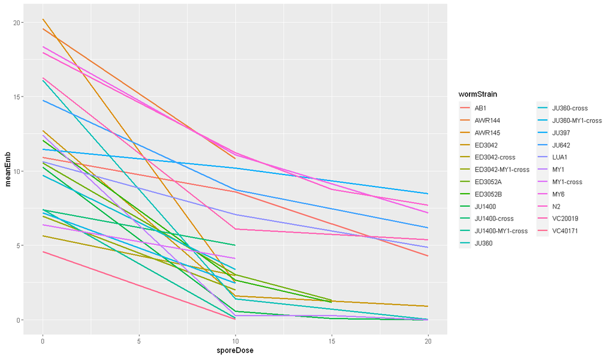

```r
# Pass the data on
split_embryo_long.df %>%

# filter the data by spore type and timepoint
filter(sporeStrain == "LUAm1", expTimepoint == 72) %>%

# Group the data before summarising it
group_by(wormStrain, sporeStrain, sporeDose) %>%

# Summarise the data to get overall mean embryo counts
summarize(meanEmb = mean(embryos)) %>%

# Plot the data
ggplot(data = .) +
    # Set the x and y axis variables, and how you want to colour the lines
    aes(x = sporeDose, y = meanEmb, colour = wormStrain) +
    # Set the type of visualization to a line graph
    geom_line(size=1)
```

## 6.2.0 Generate a scatterplot from `gapminder_long` data

Recall that our gapminder data carries some basic information such as GDP and life expectancy across multiple multiple countries at multiple points in time. Let's take a more wholesale look at this data and ask if there appears to be a relationship between life expectancy and GDP. We'll focus just on one year of data to filter out other effects that might be dependent upon the year the data was collected.

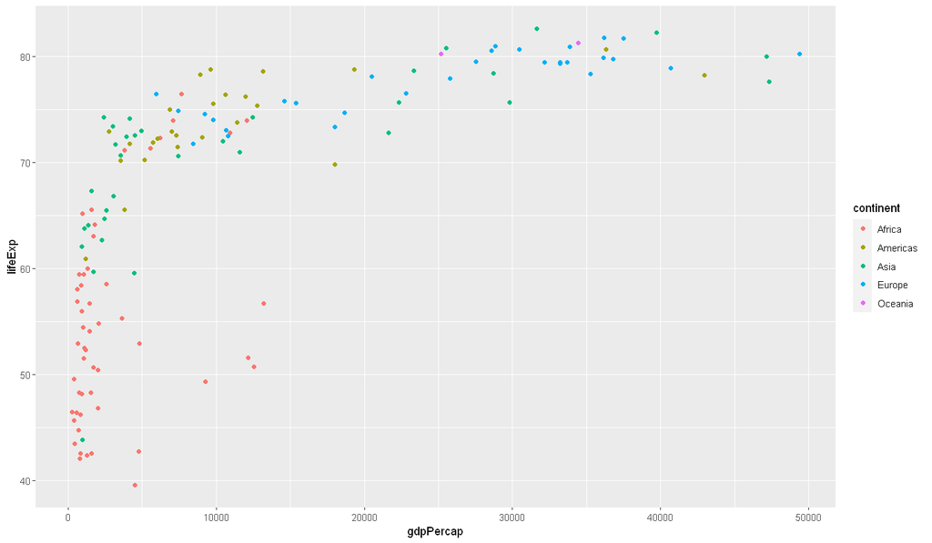

```r
# First filter gapminder_long
gapminder_long %>%
filter(year == 2007) %>% # Take a look at just data from our last snapshot year: 2007
# Pass the data to ggplot
ggplot(data = .)+
    # Tell ggplot which columns to draw data from
    aes(x = gdpPercap, y = lifeExp, colour = continent) +
    # Define how you want the plot to be visualized
    geom_point()
```

With just a few lines of code, we can see that the overall trend suggests that life expectancy is positively correlated with GDP. It's not always the case, from the look of some African countries, but that's the general trend we see from a 2007 snapshot of data. Next week we'll learn even more about using `ggplot` to visualize our data and customize its presentation.

# 7.0.0 Class summary

That's the end for our third class on R! You've made it through and we've learned about the following:

1. The tidy data format and philosophy.
2. Converting wide format data to long format.
3. Splitting multivariable columns
4. Grouping and summarising data.
5. Pivoting a multiple observation column to single observation variables
6. Returning data to a wide format
7. Joining/merging data across data sets
8. A small taste of visualizing data with `ggplot`

## 7.1.0 Submit your completed skeleton notebook (2% of final grade)

At the end of this lecture a Quercus assignment portal will be available to submit your completed skeletons from today (including the comprehension question answers!). These will be due one week later, before the next lecture. Each lecture skeleton is worth 2% of your final grade but a **bonus 0.7%** will also be awarded for submissions made within 24 hours from the end of lecture (ie 1600 hours the following day).

## 7.2.0 Post-lecture assessment (9% of final grade)

Soon after the end of this lecture, a homework assignment will be available for you in [DataCamp](https://www.datacamp.com/). Your assignment is to complete two chapters from the **Reshaping Data with tidyr** course: Tidy data (950 points) and From wide to long and back (1300 points). This is a pass-fail assignment, and in order to pass you need to achieve a least 1,687 points (75%) of the total possible points. Note that when you take hints from the DataCamp chapter, it will reduce your total earned points for that chapter.

In order to properly assess your progress on DataCamp, at the end of each chapter, please take a screenshot of the *entire* course summary. You'll see this under the "Course Outline" menubar seen at the top of the page for each course and you'll want to expand each section. It should look something like this:

[figure not shown]

You may need to take several screenshots if you cannot print it all in a single try. Submit the file(s) or a combined PDF for the homework to the assignment section of Quercus. By submitting your scores for each section, and chapter, we can keep track of your progress, identify knowledge gaps, and produce a standardized way for you to check on your assignment "grades" throughout the course.

You will have until 12:59 hours on Wednesday, September 28th to submit your assignment (right before the next lecture).

## 7.3.0 Acknowledgements

**Revision 1.0.0**: materials prepared in R Markdown by Oscar Montoya, M.Sc. *Bioinformatician, Education and Outreach, CAGEF.*

**Revision 1.1.0**: edited and prepared for **CSB1020H F LEC0142**, 09-2021 by Calvin Mok, Ph.D. *Bioinformatician, Education and Outreach, CAGEF.*

**Revision 1.1.1**: edited and prepared for **CSB1020H F LEC0142**, 09-2022 by Calvin Mok, Ph.D. *Bioinformatician, Education and Outreach, CAGEF.*

## 7.4.0 Your DataCamp academic subscription

This class is supported by DataCamp, the most intuitive learning platform for data science and analytics. Learn any time, anywhere and become an expert in R, Python, SQL, and more. DataCamp’s learn-by-doing methodology combines short expert videos and hands-on-the-keyboard exercises to help learners retain knowledge. DataCamp offers 350+ courses by expert instructors on topics such as importing data, data visualization, and machine learning. They’re constantly expanding their curriculum to keep up with the latest technology trends and to provide the best learning experience for all skill levels. Join over 6 million learners around the world and close your skills gap.

Your DataCamp academic subscription grants you free access to the DataCamp's catalog for 6 months from the beginning of this course. You are free to look for additional tutorials and courses to help grow your skills for your data science journey. Learn more (literally!) at [DataCamp.com](https://learn.datacamp.com/).

## 7.5.0 Resources

https://github.com/wmhall/tidyr_lesson/blob/master/tidyr_lesson.md  
http://vita.had.co.nz/papers/tidy-data.pdf  
https://thinkr.fr/tidyverse-hadleyverse/  
http://stat545.com/bit001_dplyr-cheatsheet.html  
http://dplyr.tidyverse.org/articles/two-table.html

[figure not shown]